# Statistical project

Brenda Téllez, Abishek Varma, Huzaifa Fazal

2022-07-17

# Setting up the working directory

```r
#setwd("~/UNIPD/statistic 2/st")
setwd("C:/Users/asus/Desktop/Masters/statistical learning/MOD.B/project")
```

Importing the libraries

```r
library(dlookr)
library(readr)
library(lattice)
library(modelr)
library(MASS)
#library(rgl)
library(fastDummies)
library(recipes)
library(dummy)
library(zoo)
```

```r
library(ggstatsplot)
library(inspectdf)
library(ggplot2)
library(ggthemes)
library(vcd)
library(ggmosaic)
library(GGally)
library(caTools)
library(plyr)
library(stringr)
library(scales)
library(dplyr)
library(VIM)
library(naniar)
library(egg)
```

#Introduction • Introduction A common practice to enhance and stimulate business growth is using marketing campaigns. Marketing campaigns come in many different forms, ranging from acquisition marketing campaigns to social media marketing campaigns. A common and widely used marketing campaign is the telemarketing strategy that banks oftentimes utilize due to the complex nature of financial products that require more nuanced explanations. However, telemarketing campaigns are demanding in terms of time, effort and resources needed. Therefore, it is of big significance to determine what factors associated with telemarketing, and/or otherwise, affect whether a client purchases financial products or not.

The dataset contains data from a Portuguese commercial bank that details various bank-client relationship information. Using this information, we generated models to predict the outcome of purchase decisions of clients.

# Data Collection

This project uses a dataset that is originally sourced from a Portuguese retail bank and was used by [S. Moro, P.cortez and P. Rita}. The dataset contains features related to direct marketing campaigns for the purpose of selling bank long-term deposits. We obtained the dataset from the UC Irvine Machine Learning Repository.

```r
bank <- read.csv("bank-additional-full.csv", sep=";", na="unknown")
```

```r
summary(bank)
```

```
##       age            job              marital           education
##  Min.   :17.00   Length:41188       Length:41188       Length:41188
##  1st Qu.:32.00   Class :character   Class :character   Class :character
##  Median :38.00   Mode  :character   Mode  :character   Mode  :character
##  Mean   :40.02
##  3rd Qu.:47.00
##  Max.   :98.00
##    default            housing              loan             contact
##  Length:41188       Length:41188       Length:41188       Length:41188
##  Class :character   Class :character   Class :character   Class :character
##  Mode  :character   Mode  :character   Mode  :character   Mode  :character
##
##
##
##     month           day_of_week           duration         campaign
##  Length:41188       Length:41188       Min.   :   0.0   Min.   : 1.000
##  Class :character   Class :character   1st Qu.: 102.0   1st Qu.: 1.000
##  Mode  :character   Mode  :character   Median : 180.0   Median : 2.000
##                                        Mean   : 258.3   Mean   : 2.568
##                                        3rd Qu.: 319.0   3rd Qu.: 3.000
##                                        Max.   :4918.0   Max.   :56.000
##      pdays          previous       poutcome          emp.var.rate
##  Min.   :  0.0   Min.   :0.000   Length:41188       Min.   :-3.40000
##  1st Qu.:999.0   1st Qu.:0.000   Class :character   1st Qu.:-1.80000
##  Median :999.0   Median :0.000   Mode  :character   Median : 1.10000
##  Mean   :962.5   Mean   :0.173                      Mean   : 0.08189
##  3rd Qu.:999.0   3rd Qu.:0.000                      3rd Qu.: 1.40000
##  Max.   :999.0   Max.   :7.000                      Max.   : 1.40000
##  cons.price.idx  cons.conf.idx     euribor3m      nr.employed
##  Min.   :92.20   Min.   :-50.8   Min.   :0.634   Min.   :4964
##  1st Qu.:93.08   1st Qu.:-42.7   1st Qu.:1.344   1st Qu.:5099
##  Median :93.75   Median :-41.8   Median :4.857   Median :5191
##  Mean   :93.58   Mean   :-40.5   Mean   :3.621   Mean   :5167
##  3rd Qu.:93.99   3rd Qu.:-36.4   3rd Qu.:4.961   3rd Qu.:5228
##  Max.   :94.77   Max.   :-26.9   Max.   :5.045   Max.   :5228
##       y
##  Length:41188
##  Class :character
##  Mode  :character
##
##
##
```

```r
str(bank)
```

```
## 'data.frame':    41188 obs. of  21 variables:
##  $ age           : int  56 57 37 40 56 45 59 41 24 25 ...
##  $ job           : chr  "housemaid" "services" "services" "admin." ...
##  $ marital       : chr  "married" "married" "married" "married" ...
##  $ education     : chr  "basic.4y" "high.school" "high.school" "basic.6y" ...
##  $ default       : chr  "no" NA "no" "no" ...
##  $ housing       : chr  "no" "no" "yes" "no" ...
##  $ loan          : chr  "no" "no" "no" "no" ...
##  $ contact       : chr  "telephone" "telephone" "telephone" "telephone" ...
##  $ month         : chr  "may" "may" "may" "may" ...
##  $ day_of_week   : chr  "mon" "mon" "mon" "mon" ...
##  $ duration      : int  261 149 226 151 307 198 139 217 380 50 ...
##  $ campaign      : int  1 1 1 1 1 1 1 1 1 1 ...
##  $ pdays         : int  999 999 999 999 999 999 999 999 999 999 ...
##  $ previous      : int  0 0 0 0 0 0 0 0 0 0 ...
##  $ poutcome      : chr  "nonexistent" "nonexistent" "nonexistent" "nonexistent" ...
##  $ emp.var.rate  : num  1.1 1.1 1.1 1.1 1.1 1.1 1.1 1.1 1.1 1.1 ...
##  $ cons.price.idx: num  94 94 94 94 94 ...
##  $ cons.conf.idx : num  -36.4 -36.4 -36.4 -36.4 -36.4 -36.4 -36.4 -36.4 -36.4 -36.4 ...
##  $ euribor3m     : num  4.86 4.86 4.86 4.86 4.86 ...
##  $ nr.employed   : num  5191 5191 5191 5191 5191 ...
##  $ y             : chr  "no" "no" "no" "no" ...
```

Renaming columns For ease of coding and a proper standard among the columns names we remaned the columns with slight modifications as shown below.

```r
colnames(bank) <- c("Age", "Job", "Marital", "Education","Default","Housing" ,"Loan","Contact","Month","Last.Contact.Day",  "Duration", "Campaign" ,"Pdays" , "Previous.Contacts" , "Poutcome", "Emp.var.rate","Cons.price.idx", "Cons.conf.idx" ,
"Euribor3m", "Employment.number","y")
columns <- colnames(bank)
Factorcols <- c("Job", "Marital", "Default","Education","Housing" ,"Loan","Contact","Month","Last.Contact.Day", 'Poutcome', 'y')
```

Removing the dot in the “admin.” value in the job column

```r
bank$Job = str_replace(bank$Job,"[.]","istration")
```

data type of columns

```r
sapply(bank, class)
```

```
##               Age               Job           Marital         Education
##         "integer"       "character"       "character"       "character"
##           Default           Housing              Loan           Contact
##       "character"       "character"       "character"       "character"
##             Month  Last.Contact.Day          Duration          Campaign
##       "character"       "character"         "integer"         "integer"
##             Pdays Previous.Contacts          Poutcome      Emp.var.rate
##         "integer"         "integer"       "character"         "numeric"
##    Cons.price.idx     Cons.conf.idx         Euribor3m Employment.number
##         "numeric"         "numeric"         "numeric"         "numeric"
##                 y
##       "character"
```

##keeping a copy of original dataframe

```r
data <- data.frame(bank)
```

#Data cleaning

##Handling null values

- percentage of null values (can we add these percentages to graph below?)

```r
sapply(bank, function(x) round((sum(is.na(x))/length(x))*100,2))
```

```
##               Age               Job           Marital         Education
##              0.00              0.80              0.19              4.20
##           Default           Housing              Loan           Contact
##             20.87              2.40              2.40              0.00
##             Month  Last.Contact.Day          Duration          Campaign
##              0.00              0.00              0.00              0.00
##             Pdays Previous.Contacts          Poutcome      Emp.var.rate
##              0.00              0.00              0.00              0.00
##    Cons.price.idx     Cons.conf.idx         Euribor3m Employment.number
##              0.00              0.00              0.00              0.00
##                 y
##              0.00
```

Visualizing missing data

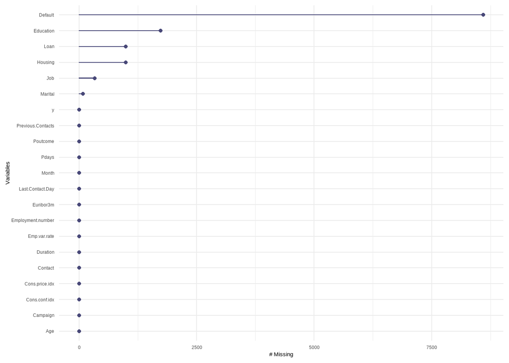

```r
gg_miss_var(bank)
```

For handling the rest of the NA values, we took 2 different approaches. First, where NA values are considered as NA values and therefore dealt with either deletion or imputations. Second, where NA values, that were originally labelled as “unknown” in the dataset, are considered as a separate category in their respective column. For example, the default column details whether a client has credit in default or not - which translates to “yes” or “no”. However, in real-world scenarios it is very plausible for their to exist a third category where a client may choose to not answer questions regarding their credit in default status. Questions such as credit in default, loans, etc can be a sensitive topic and therefore clients may choose not to comment on these questions. Therefore, we decided that “unknown” entries in the default column should be considered as one of the options for a response. Therefore, the default column has 3 possible responses/categories: yes, no, or unknown.

For the Education column, NA values were dealt with using imputations. Using a contingency table between Education and job, simple logical inferences were made between the a client’s job and their education. For example, most clients that have a management job are most likely to have a university degree. Most clients that have a services job are most likely to have a high school education. Therefore, using these inferences we imputed the NA values of the Education column. Similarly, imputations were made for the Job column. If client’s age is greater or equal to 66 and Job column is equal to NA then we imputted the missing value to retired.

For Housing, Loan, and Default columns the NA values were replaced back to “unknown” values as they will be considered as a category within their respective columns, as discussed before.

##contingency table to infer job from education and viz

```r
JobvsEd <- table(bank$Job,bank$Education,useNA = "always")
JobvsEd
```

```
##
##                  basic.4y basic.6y basic.9y high.school illiterate
##   administration       77      151      499        3329          1
##   blue-collar        2318     1426     3623         878          8
##   entrepreneur        137       71      210         234          2
##   housemaid           474       77       94         174          1
##   management          100       85      166         298          0
##   retired             597       75      145         276          3
##   self-employed        93       25      220         118          3
##   services            132      226      388        2682          0
##   student              26       13       99         357          0
##   technician           58       87      384         873          0
##   unemployed          112       34      186         259          0
##   <NA>                 52       22       31          37          0
##
##                  professional.course university.degree <NA>
##   administration                 363              5753  249
##   blue-collar                    453                94  454
##   entrepreneur                   135               610   57
##   housemaid                       59               139   42
##   management                      89              2063  123
##   retired                        241               285   98
##   self-employed                  168               765   29
##   services                       218               173  150
##   student                         43               170  167
##   technician                    3320              1809  212
##   unemployed                     142               262   19
##   <NA>                            12                45  131
```

filling null values of job based on Age

```r
bank$Job[bank$Age >= 66 & is.na(bank$Job)] <- "retired"
```

filling the null values for education

```r
remove_null_Ed <- function(bank, tab){
  for(column in unique(bank$Job[!is.na(bank$Job)])){
    bank$Education[bank$Job==column & is.na(bank$Education)] <- names(which.max(tab[column,]))
  }
  return(bank)
}
```

```r
bank <- remove_null_Ed(bank, JobvsEd)
```

filling the null values for Job

```r
remove_null_Job <- function(bank, tab){
  for(column in unique(bank$Education[!is.na(bank$Education)])){
    bank$Job[bank$Education==column & is.na(bank$Job)] <- names(which.max(tab[,column]))
  }
  return(bank)
}
```

```r
bank <- remove_null_Job(bank, JobvsEd)
```

contingency for personal and housing loan

```r
table(bank$Housing,bank$Loan,useNA = "always")
```

```
##
##           no   yes  <NA>
##   no   16065  2557     0
##   yes  17885  3691     0
##   <NA>     0     0   990
```

replacing with unknowns

```r
bank$Housing[is.na(bank$Housing)] <- "unknown"
bank$Loan[is.na(bank$Loan)] <- "unknown"
bank$Default[is.na(bank$Default)] <- "unknown"
```

null values in marital

```r
sum(is.na(bank$Marital))
```

```
## [1] 80
```

removing rows with marital, Job or education as null

```r
bank <- na.omit(bank)
```

Again visualize missing

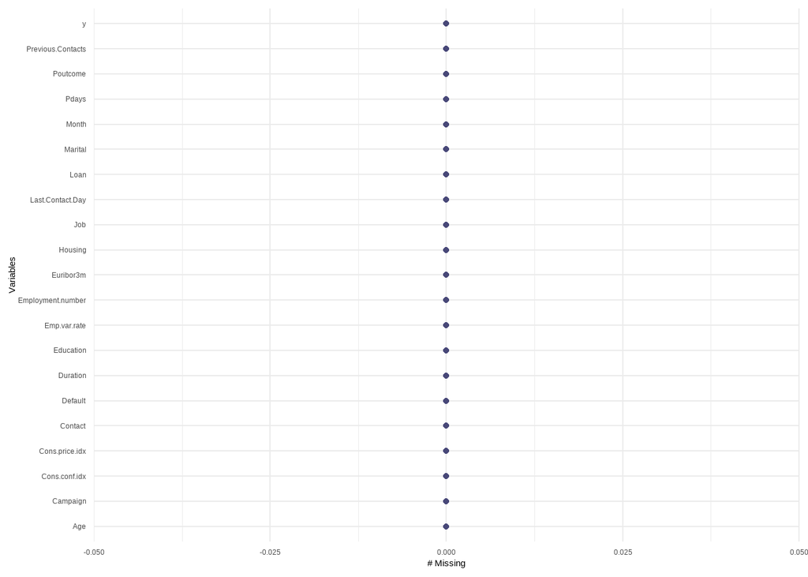

```r
gg_miss_var(bank)
```

**End of handling Missing Values**

##data transformations

All categorical columns were assigned to the factors datatype for the ease of using them in various prediction models. Some of the categorical columns were ordinal while others were nominal. Education, Month, and day_of_week are ordinal columns and thus they were assigned as an ordered factor. Job, marital, housing, loan, etc were assigned as unordered factors. However, after using ordered factor columns in our prediction models, we realised there was not much benefit in using them while it caused minor complications in some models. Therefore, we instead chnaged all categorical columns to unordered factor columns.

Feature scaling was used for all the numerical variables using MinMax scaling to normalize the range of the variables and ensure the prediction models work properly. reorder the row indices.

```r
rownames(bank) <- 1:nrow(bank)
```

##Converting character types to factors

```r
bank[Factorcols] <- lapply(bank[Factorcols], as.factor)
```

```r
str(bank)
```

```
## 'data.frame':    40990 obs. of  21 variables:
##  $ Age              : int  56 57 37 40 56 45 59 41 24 25 ...
##  $ Job              : Factor w/ 11 levels "administration",..: 4 8 8 1 8 8 1 2 10 8 ...
##  $ Marital          : Factor w/ 3 levels "divorced","married",..: 2 2 2 2 2 2 2 2 3 3 ...
##  $ Education        : Factor w/ 7 levels "basic.4y","basic.6y",..: 1 4 4 2 4 3 6 3 6 4 ...
##  $ Default          : Factor w/ 3 levels "no","unknown",..: 1 2 1 1 1 2 1 2 1 1 ...
##  $ Housing          : Factor w/ 3 levels "no","unknown",..: 1 1 3 1 1 1 1 1 3 3 ...
##  $ Loan             : Factor w/ 3 levels "no","unknown",..: 1 1 1 1 3 1 1 1 1 1 ...
##  $ Contact          : Factor w/ 2 levels "cellular","telephone": 2 2 2 2 2 2 2 2 2 2 ...
##  $ Month            : Factor w/ 10 levels "apr","aug","dec",..: 7 7 7 7 7 7 7 7 7 7 ...
##  $ Last.Contact.Day : Factor w/ 5 levels "fri","mon","thu",..: 2 2 2 2 2 2 2 2 2 2 ...
##  $ Duration         : int  261 149 226 151 307 198 139 217 380 50 ...
##  $ Campaign         : int  1 1 1 1 1 1 1 1 1 1 ...
##  $ Pdays            : int  999 999 999 999 999 999 999 999 999 999 ...
##  $ Previous.Contacts: int  0 0 0 0 0 0 0 0 0 0 ...
##  $ Poutcome         : Factor w/ 3 levels "failure","nonexistent",..: 2 2 2 2 2 2 2 2 2 2 ...
##  $ Emp.var.rate     : num  1.1 1.1 1.1 1.1 1.1 1.1 1.1 1.1 1.1 1.1 ...
##  $ Cons.price.idx   : num  94 94 94 94 94 ...
##  $ Cons.conf.idx    : num  -36.4 -36.4 -36.4 -36.4 -36.4 -36.4 -36.4 -36.4 -36.4 -36.4 ...
##  $ Euribor3m        : num  4.86 4.86 4.86 4.86 4.86 ...
##  $ Employment.number: num  5191 5191 5191 5191 5191 ...
##  $ y                : Factor w/ 2 levels "no","yes": 1 1 1 1 1 1 1 1 1 1 ...
##  - attr(*, "na.action")= 'omit' Named int [1:198] 41 74 92 300 304 344 389 391 414 429 ...
##   ..- attr(*, "names")= chr [1:198] "41" "74" "92" "300" ...
```

#Exploratory Data Analysis

dimension of the dataset

```r
dim(bank)
```

```
## [1] 40990    21
```

There are 40990 rows and 21 columns

Taking a glance at first and last five rows

```r
head(bank)
```

|  | Age | Job | Marital | Education | Default | Housing | Loan | Contact | Month | Last.Contact.Day | Duration | Campaign | Pdays | Previous.Contacts | Poutcome | Emp.var.rate | Cons.price.idx | Cons.conf.idx | Euribor3m | Employment.number | y |
| --- | --- | --- | --- | --- | --- | --- | --- | --- | --- | --- | --- | --- | --- | --- | --- | --- | --- | --- | --- | --- | --- |
| 1 | 56 | housemaid | married | basic.4y | no | no | no | telephone | may | mon | 261 | 1 | 999 | 0 | nonexistent | 1.1 | 93.994 | -36.4 | 4.857 | 5191 | no |
| 2 | 57 | services | married | high.school | unknown | no | no | telephone | may | mon | 149 | 1 | 999 | 0 | nonexistent | 1.1 | 93.994 | -36.4 | 4.857 | 5191 | no |
| 3 | 37 | services | married | high.school | no | yes | no | telephone | may | mon | 226 | 1 | 999 | 0 | nonexistent | 1.1 | 93.994 | -36.4 | 4.857 | 5191 | no |
| 4 | 40 | administration | married | basic.6y | no | no | no | telephone | may | mon | 151 | 1 | 999 | 0 | nonexistent | 1.1 | 93.994 | -36.4 | 4.857 | 5191 | no |
| 5 | 56 | services | married | high.school | no | no | yes | telephone | may | mon | 307 | 1 | 999 | 0 | nonexistent | 1.1 | 93.994 | -36.4 | 4.857 | 5191 | no |
| 6 | 45 | services | married | basic.9y | unknown | no | no | telephone | may | mon | 198 | 1 | 999 | 0 | nonexistent | 1.1 | 93.994 | -36.4 | 4.857 | 5191 | no |

```r
tail(bank)
```

|  | Age | Job | Marital | Education | Default | Housing | Loan | Contact | Month | Last.Contact.Day | Duration | Campaign | Pdays | Previous.Contacts | Poutcome | Emp.var.rate | Cons.price.idx | Cons.conf.idx | Euribor3m | Employment.number | y |
| --- | --- | --- | --- | --- | --- | --- | --- | --- | --- | --- | --- | --- | --- | --- | --- | --- | --- | --- | --- | --- | --- |
| 40985 | 29 | unemployed | single | basic.4y | no | yes | no | cellular | nov | fri | 112 | 1 | 9 | 1 | success | -1.1 | 94.767 | -50.8 | 1.028 | 4963.6 | no |
| 40986 | 73 | retired | married | professional.course | no | yes | no | cellular | nov | fri | 334 | 1 | 999 | 0 | nonexistent | -1.1 | 94.767 | -50.8 | 1.028 | 4963.6 | yes |
| 40987 | 46 | blue-collar | married | professional.course | no | no | no | cellular | nov | fri | 383 | 1 | 999 | 0 | nonexistent | -1.1 | 94.767 | -50.8 | 1.028 | 4963.6 | no |
| 40988 | 56 | retired | married | university.degree | no | yes | no | cellular | nov | fri | 189 | 2 | 999 | 0 | nonexistent | -1.1 | 94.767 | -50.8 | 1.028 | 4963.6 | no |
| 40989 | 44 | technician | married | professional.course | no | no | no | cellular | nov | fri | 442 | 1 | 999 | 0 | nonexistent | -1.1 | 94.767 | -50.8 | 1.028 | 4963.6 | yes |
| 40990 | 74 | retired | married | professional.course | no | yes | no | cellular | nov | fri | 239 | 3 | 999 | 1 | failure | -1.1 | 94.767 | -50.8 | 1.028 | 4963.6 | no |

detailed statistics about the numerical features

```r
describe(bank)
```

| described_variables | n | na | mean | sd | se_mean | IQR | skewness | kurtosis | p00 | p01 | p05 | p10 | p20 | p25 | p30 | p40 | p50 | p60 | p70 | p75 | p80 | p90 | p95 | p99 | p100 |
| --- | --- | --- | --- | --- | --- | --- | --- | --- | --- | --- | --- | --- | --- | --- | --- | --- | --- | --- | --- | --- | --- | --- | --- | --- | --- |
| Age | 40990 | 0 | 39.99958526 | 10.4173059 | 0.051453682 | 15.000 | 0.7895061 | 0.807920103 | 17.000 | 23.00000 | 26.000 | 28.000 | 31.000 | 32.000 | 33.00 | 35.000 | 38.000 | 41.000 | 45.000 | 47.000 | 49.000 | 55.000 | 58.000 | 71.000 | 98.000 |
| Duration | 40990 | 0 | 258.32688461 | 259.3483954 | 1.280986657 | 217.000 | 3.2660855 | 20.292746080 | 0.000 | 11.00000 | 36.000 | 59.000 | 89.000 | 102.000 | 116.00 | 146.000 | 180.000 | 222.000 | 280.000 | 319.000 | 368.000 | 551.000 | 753.000 | 1271.110 | 4918.000 |
| Campaign | 40990 | 0 | 2.56528422 | 2.7661321 | 0.013662619 | 2.000 | 4.7796101 | 37.271041762 | 1.000 | 1.00000 | 1.000 | 1.000 | 1.000 | 1.000 | 1.00 | 1.000 | 2.000 | 2.000 | 3.000 | 3.000 | 3.000 | 5.000 | 7.000 | 14.000 | 56.000 |
| Pdays | 40990 | 0 | 962.56525982 | 186.6903937 | 0.922110596 | 0.000 | -4.9290023 | 22.296582551 | 0.000 | 3.00000 | 999.000 | 999.000 | 999.000 | 999.000 | 999.00 | 999.000 | 999.000 | 999.000 | 999.000 | 999.000 | 999.000 | 999.000 | 999.000 | 999.000 | 999.000 |
| Previous.Contacts | 40990 | 0 | 0.17294462 | 0.4948439 | 0.002444158 | 0.000 | 3.8347775 | 20.153432246 | 0.000 | 0.00000 | 0.000 | 0.000 | 0.000 | 0.000 | 0.00 | 0.000 | 0.000 | 0.000 | 0.000 | 0.000 | 0.000 | 1.000 | 1.000 | 2.000 | 7.000 |
| Emp.var.rate | 40990 | 0 | 0.08045621 | 1.5710700 | 0.007759908 | 3.200 | -0.7219900 | -1.065509952 | -3.400 | -3.40000 | -2.900 | -1.800 | -1.800 | -1.800 | -1.70 | -0.100 | 1.100 | 1.100 | 1.400 | 1.400 | 1.400 | 1.400 | 1.400 | 1.400 | 1.400 |
| Cons.price.idx | 40990 | 0 | 93.57523681 | 0.5787226 | 0.002858456 | 0.919 | -0.2293914 | -0.831474967 | 92.201 | 92.20100 | 92.713 | 92.893 | 92.893 | 93.075 | 93.20 | 93.444 | 93.749 | 93.918 | 93.994 | 93.994 | 93.994 | 94.465 | 94.465 | 94.465 | 94.767 |
| Cons.conf.idx | 40990 | 0 | -40.50761893 | 4.6280751 | 0.022859222 | 6.300 | 0.3046367 | -0.358069937 | -50.800 | -49.50000 | -47.100 | -46.200 | -46.200 | -42.700 | -42.70 | -42.000 | -41.800 | -40.000 | -36.400 | -36.400 | -36.400 | -36.100 | -33.600 | -26.900 | -26.900 |
| Euribor3m | 40990 | 0 | 3.61968524 | 1.7347790 | 0.008568508 | 3.617 | -0.7072457 | -1.409473458 | 0.634 | 0.65856 | 0.797 | 1.046 | 1.299 | 1.344 | 1.41 | 4.153 | 4.857 | 4.864 | 4.960 | 4.961 | 4.962 | 4.964 | 4.966 | 4.968 | 5.045 |
| Employment.number | 40990 | 0 | 5166.98231032 | 72.2687571 | 0.356953485 | 129.000 | -1.0428245 | -0.006813707 | 4963.600 | 4963.60000 | 5008.700 | 5076.200 | 5099.100 | 5099.100 | 5099.10 | 5191.000 | 5191.000 | 5195.800 | 5228.100 | 5228.100 | 5228.100 | 5228.100 | 5228.100 | 5228.100 | 5228.100 |

From the basic statistics and summary of the numerical columns, we can observe a few intersting things about the mean, median, min, max, etc. First, regarding the Pdays columns, it can be observed the mean is 962.6. The median and the max equals to 999 of the Pdays columns. At first glance this seems strange and is misleading, but it is due to the fact that the way the data was recorded. In the Pdays column, if a client was not contacted after a previous campaign then it is recorded as 999. It could be questioned why not record that as “0”. This is because “0” values in the pdays column signifies that at the time of recording/collecting this data, there have been 0 days since the previous contact. i.e the client was contacted on the same day as the data was collected. What the pdays mean of 962.6 and median of 999 tells us is that the vast majority of clients were not contacted since the previous campaign.

The table shows the mean, median and max of Pdays if we remove all the 999 entries.

```r
summary(bank$Pdays[bank$Pdays!=999])
```

```
##    Min. 1st Qu.  Median    Mean 3rd Qu.    Max.
##   0.000   3.000   6.000   6.008   7.000  27.000
```

We considered changing the 999 values to something else as it might skew the prediction models to larger values. However, we realised it is unnecessary as results from the prediction can be interpreted using some threshold instead. If pdays values is considerably high, then that can be simply interpreted as ‘not previously contacted’.

Age and Campaign columns have reasonable mean and median values, which are close to each other. The ‘Previous’ column has a mean of 0.1729 and median of 0. As the previous column details the number of contacts performed before the current campaign, the mean and median suggest that the majority of clients were not contacted previously. This indicates that the bank is mostly focused on targeting new customers with their campaigns (as no previous contacts have been made) or the bank has only recently started contacting customers for telemarketing purposes.

Nothing noteworthy is dsiplayed about the mean and medians of the economical, social data columns.

```r
bank %>% inspect_types()
```

| type | cnt | pcnt | col_name |
| --- | --- | --- | --- |
| factor | 11 | 52.38095 |  |
| integer | 5 | 23.80952 |  |
| numeric | 5 | 23.80952 |  |

**Insights**: - There are 11 factor columns - There are 5 integer columns - There are 5 numeric columns

```r
bank%>%inspect_cat()
```

| col_name | cnt | common | common_pcnt | levels |
| --- | --- | --- | --- | --- |
| Contact | 2 | cellular | 63.50817 |  |
| Default | 3 | no | 79.21200 |  |
| Education | 7 | university.degree | 30.77336 |  |
| Housing | 3 | yes | 52.39571 |  |
| Job | 11 | administration | 25.57941 |  |
| Last.Contact.Day | 5 | thu | 20.90754 |  |
| Loan | 3 | no | 82.41522 |  |
| Marital | 3 | married | 60.56111 |  |
| Month | 10 | may | 33.42035 |  |
| Poutcome | 3 | nonexistent | 86.34057 |  |

[output cut: 1 more lines]

The table above shows the most common category in each column with their respective percentages. In general columns that have multiple categories have lower percentages of the most common category. Columns such as default, loan, poutcome that have 2 or 3 categories are most imbalanced than the rest. It also interesting to see the most common education level and jobs of the clients that were contacted. 82.4% of the contacted clients dont have personal loans.

## Univariate Analysis

collecting columns of factor type

```r
factors <- subset(bank,select = names(Filter(is.factor,bank)))
```

```r
summary(factors)
```

```
##              Job            Marital                    Education
##  administration:10485   divorced: 4611   basic.4y           : 4318
##  blue-collar   : 9344   married :24824   basic.6y           : 2286
##  technician    : 6743   single  :11555   basic.9y           : 6489
##  services      : 3963                    high.school        : 9817
##  management    : 2921                    illiterate         :   18
##  retired       : 1725                    professional.course: 5448
##  (Other)       : 5809                    university.degree  :12614
##     Default         Housing           Loan            Contact
##  no     :32469   no     :18526   no     :33782   cellular :26032
##  unknown: 8518   unknown:  987   unknown:  987   telephone:14958
##  yes    :    3   yes    :21477   yes    : 6221
##
##
##
##
##      Month       Last.Contact.Day        Poutcome       y
##  may    :13699   fri:7796         failure    : 4236   no :36371
##  jul    : 7148   mon:8467         nonexistent:35391   yes: 4619
##  aug    : 6135   thu:8570         success    : 1363
##  jun    : 5284   tue:8056
##  nov    : 4092   wed:8101
##  apr    : 2627
##  (Other): 2005
```

##Barcharts

The barcharts below shows that our dataset is highly imbalanced. The y-output has 36371 ‘No’ values and 4619 ‘Yes’ values. That is almost an imbalance ratio of 8:1 with 88.7% of the responses refusing the long-term deposit.

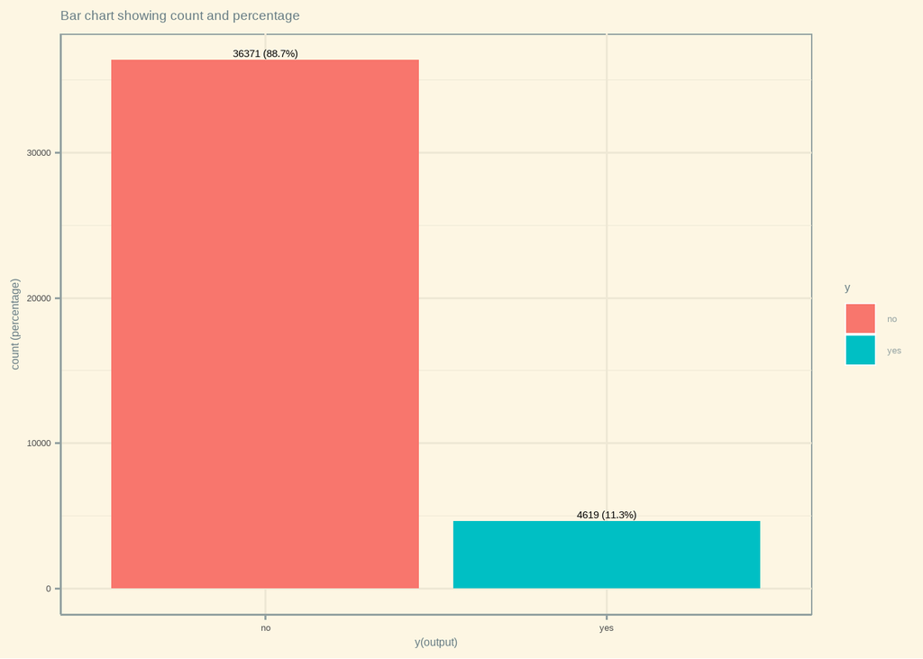

```r
OutputCount <- factors%>%
            dplyr::count(y)%>%
            dplyr::mutate(perc = n/sum(n) * 100)

pl <- ggplot (data = OutputCount, aes(x = y, y = n, fill = y))
pl <- pl + geom_col()
pl <- pl + geom_text(aes(x = y, y = n
                         , label = paste0(n, " (", round(perc,1),"%)")
                         , vjust = -0.5
                         ))
pl <- pl + theme_solarized() + scale_colour_solarized("red")
pl <- pl + labs(title ="Bar chart showing count and percentage", x="y(output)", y="count (percentage)")
pl
```

collecting columns of numeric type

```r
numerics <- subset(bank,select = names(Filter(is.numeric,bank)))
```

##Histogram with Density plot

We used histograms with density plots to analyse the distribution of the various various that we will be using as predicting factors.

```r
distplotsnumerics <- function(bank,numerics){
  for(col in names(numerics)){
    distplot <- ggplot(numerics, aes(x = bank[[col]])) +
    geom_histogram(aes(y = ..density..),
                   colour = 1, fill = "lightgreen", bins = 20) +
    geom_density(lwd = 1, colour = 4,
                 fill = 1, alpha = 0.25) + labs(x = col)
    print(distplot)
  }
}
```

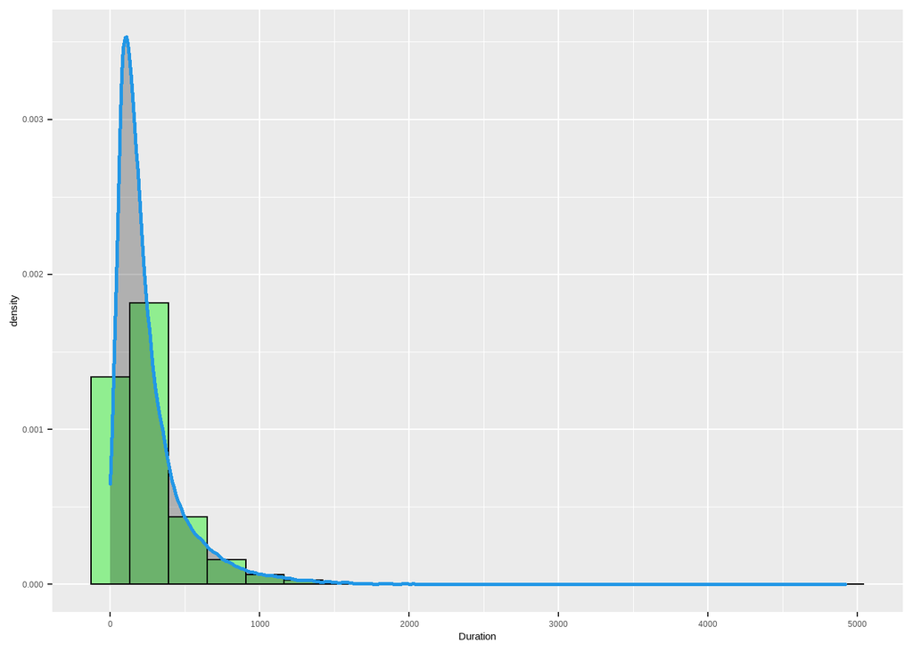

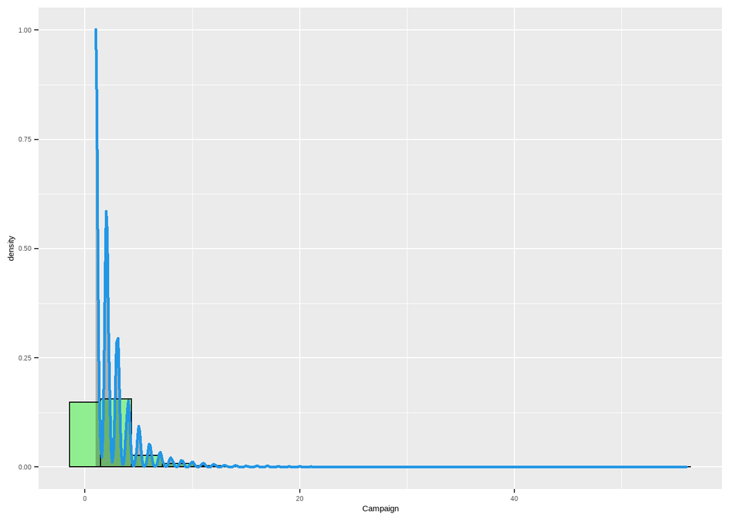

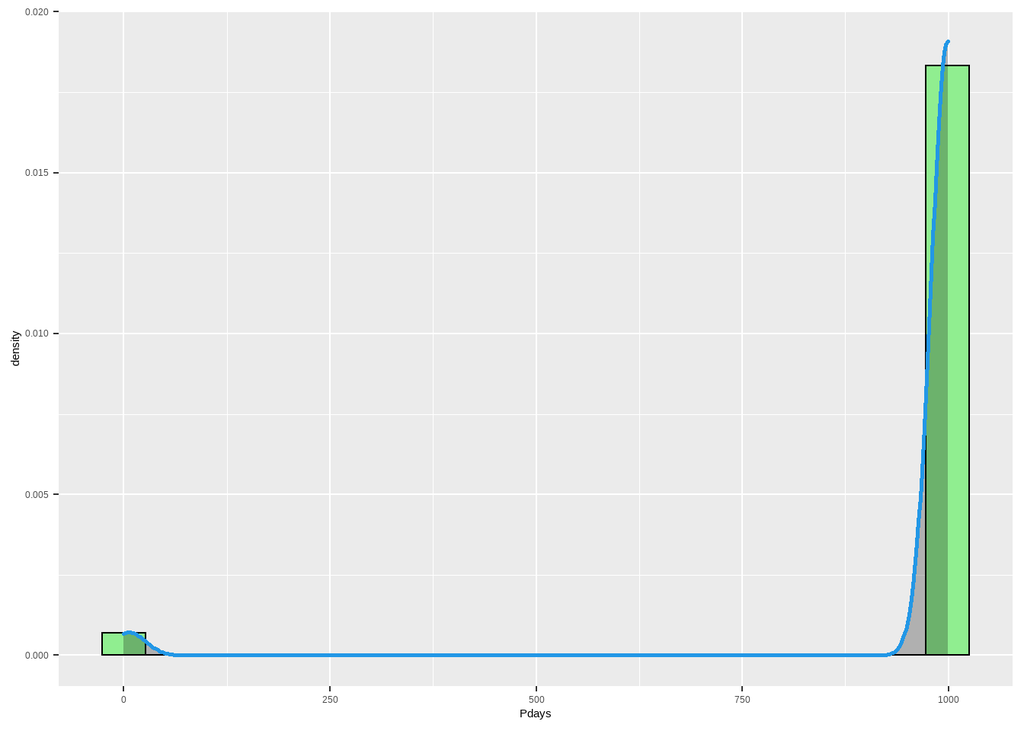

```r
distplotsnumerics(bank,numerics[,2:4])
```

Last 50 columns in descending order of Duration

```r
head(bank[order(bank$Duration, decreasing= T),], n = 50)
```

|  | Age | Job | Marital | Education | Default | Housing | Loan | Contact | Month | Last.Contact.Day | Duration | Campaign | Pdays | Previous.Contacts | Poutcome | Emp.var.rate | Cons.price.idx | Cons.conf.idx | Euribor3m | Employment.number | y |
| --- | --- | --- | --- | --- | --- | --- | --- | --- | --- | --- | --- | --- | --- | --- | --- | --- | --- | --- | --- | --- | --- |
| 23950 | 33 | technician | single | professional.course | no | yes | no | telephone | nov | mon | 4918 | 1 | 999 | 0 | nonexistent | -0.1 | 93.200 | -42.0 | 4.406 | 5195.8 | no |
| 22071 | 52 | blue-collar | married | basic.4y | no | no | no | telephone | aug | thu | 4199 | 3 | 999 | 0 | nonexistent | 1.4 | 93.444 | -36.1 | 4.963 | 5228.1 | yes |
| 40342 | 27 | administration | single | high.school | no | no | no | telephone | aug | fri | 3785 | 1 | 999 | 0 | nonexistent | -1.7 | 94.027 | -38.3 | 0.888 | 4991.6 | no |
| 13742 | 31 | technician | married | professional.course | no | no | no | cellular | jul | thu | 3643 | 1 | 999 | 0 | nonexistent | 1.4 | 93.918 | -42.7 | 4.963 | 5228.1 | yes |
| 7680 | 37 | unemployed | married | professional.course | no | yes | no | telephone | may | fri | 3631 | 2 | 999 | 0 | nonexistent | 1.1 | 93.994 | -36.4 | 4.864 | 5191.0 | yes |
| 35868 | 28 | blue-collar | married | basic.9y | no | yes | no | cellular | may | tue | 3509 | 2 | 3 | 2 | success | -1.8 | 92.893 | -46.2 | 1.266 | 5099.1 | no |
| 19518 | 47 | management | married | high.school | no | no | no | cellular | aug | thu | 3422 | 1 | 999 | 0 | nonexistent | 1.4 | 93.444 | -36.1 | 4.968 | 5228.1 | no |
| 2294 | 39 | self-employed | married | basic.4y | unknown | yes | no | telephone | may | tue | 3366 | 3 | 999 | 0 | nonexistent | 1.1 | 93.994 | -36.4 | 4.856 | 5191.0 | no |
| 20876 | 47 | administration | married | high.school | no | yes | yes | cellular | aug | thu | 3322 | 1 | 999 | 0 | nonexistent | 1.4 | 93.444 | -36.1 | 4.964 | 5228.1 | no |
| 23903 | 27 | blue-collar | single | professional.course | no | yes | no | telephone | oct | mon | 3284 | 1 | 999 | 0 | nonexistent | -0.1 | 93.798 | -40.4 | 4.912 | 5195.8 | no |

[output cut: 40 more lines]

# Log transformation for right skewed features

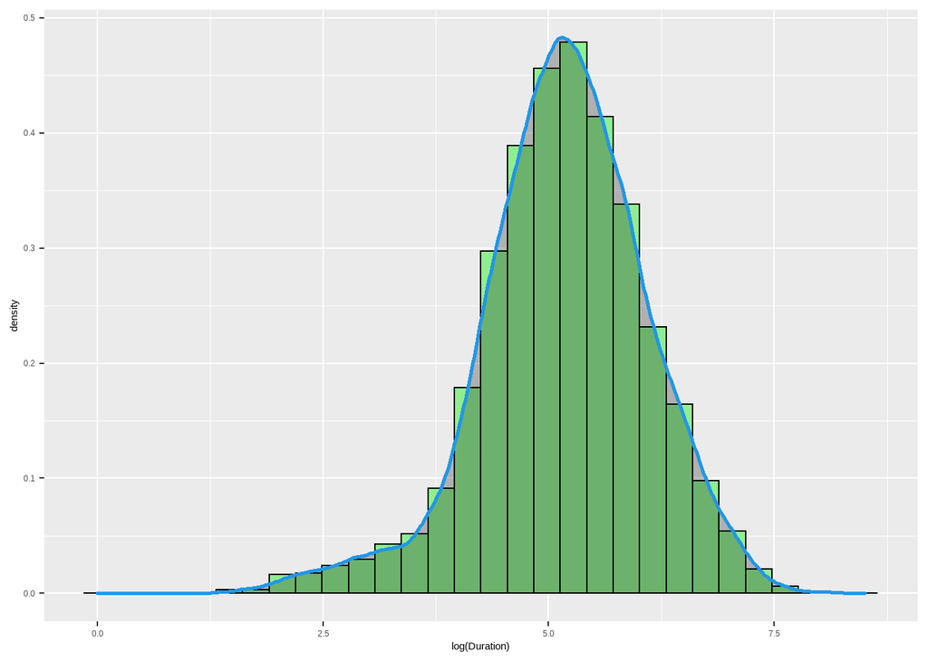

```r
logpn1 <-ggplot(numerics, aes(x = log(Duration))) +
  geom_histogram(aes(y = ..density..),
                 colour = 1, fill = "lightgreen") +
  geom_density(lwd = 1, colour = 4,
               fill = 1, alpha = 0.25, bins = 20)
logpn1
```

## Overlay densityplots for age

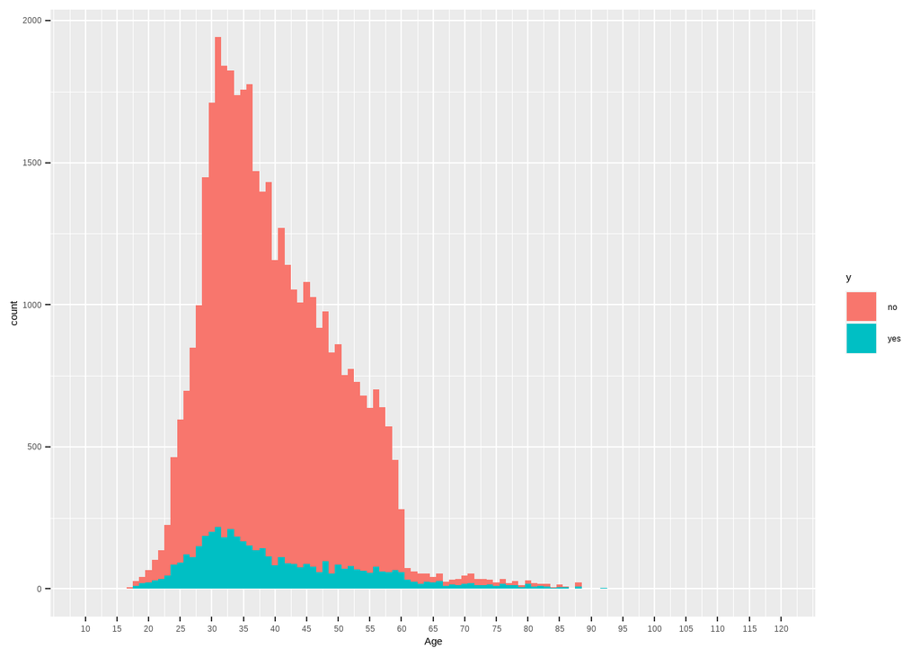

```r
ggplot(bank,aes(x=Age, fill=y)) + geom_histogram(binwidth = 1) + scale_x_continuous(breaks = seq(10, 120, 5), lim = c(10, 120))
```

The overlay of the two histograms of both the subscribed (yes) and unsubscribed (no) clients against the age variable illustrates a big gap in the count of each age group among ‘yes’ and ‘no’. There are considerably less clients who subscribed to the term deposit than those that declined in each age category. It can be observed that the age group that was cotacted the most frequently, in general, also responded positively to subscribing to a term deposit - the highest bin for the ‘yes’ respondents corresponds with the bin (age) that was contacted the most.

FOR THIS: MONTH AND DAY AS WELL Job vs y and Education vs Y

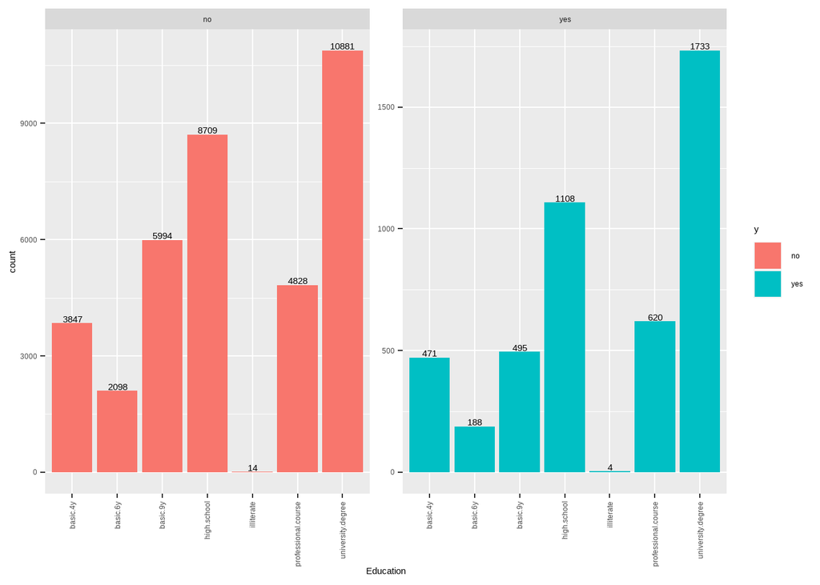

```r
ggplot(bank,aes(x=Education, fill=y)) + geom_bar(position = "dodge") + geom_text(aes(label=..count..),stat='count',position=position_dodge(0.9),vjust=-0.2) + theme(axis.text.x=element_text(angle=90,hjust=1,vjust=0.5)) + facet_wrap(~y, scales = "free_y")
```

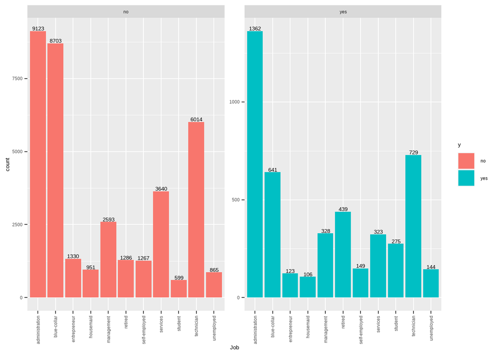

```r
ggplot(bank,aes(x=Job, fill=y)) + geom_bar() + geom_bar(position = "dodge") + geom_text(aes(label=..count..),stat='count',position=position_dodge(0.9),vjust=-0.2) + theme(axis.text.x=element_text(angle=90,hjust=1,vjust=0.5))+ facet_wrap(~y,scales = "free_y")
```

Duration has lot of outliers

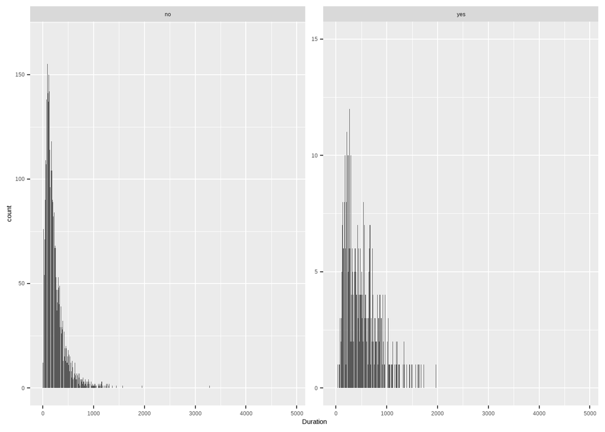

```r
ggplot(bank,aes(x=Duration)) + geom_bar() + facet_wrap(~y, scales = "free_y") + scale_color_brewer(palette="Dark2")
```

In the bar chart of the duration column, it can be noted that when clients refuse to subscribe to a term deposit then the call duration are mostly towards the low end. This can be explained that when clients are certain they don’t want to subscribe to the term deposit then refuse early on in the call and the call ends. However, when clients ended-up successfully subscribing to term deposits then it can be seen that call durations are longer on average - observed from the slightly less positively skewed chart of the ‘yes’ respondents when compared to the chart of the ‘no’ respondent. This is mostly due to the extra time needed to either clarify or convince a client regarding the details of the term deposit.

#Boxplots

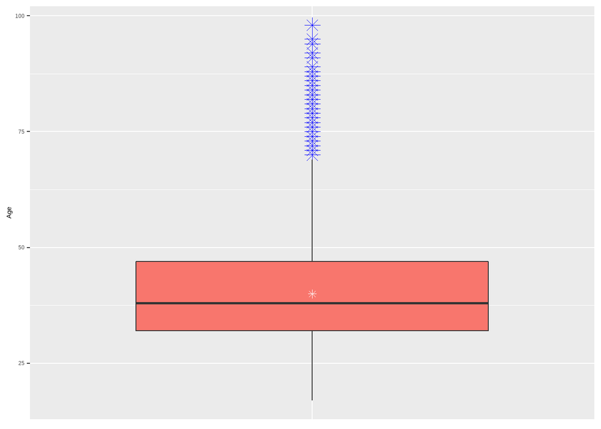

```r
bp1 <- ggplot(numerics, aes(x = factor(0), y = Age, fill = factor(0))) +
  geom_boxplot(outlier.colour="blue", outlier.shape=8, outlier.size=4) +
  theme(axis.title.x=element_blank(),axis.text.x=element_blank(),axis.ticks.x=element_blank(),legend.position="none")+
  stat_summary(fun = "mean", geom = "point", shape = 8,
               size = 2, color = "white")
bp1
```

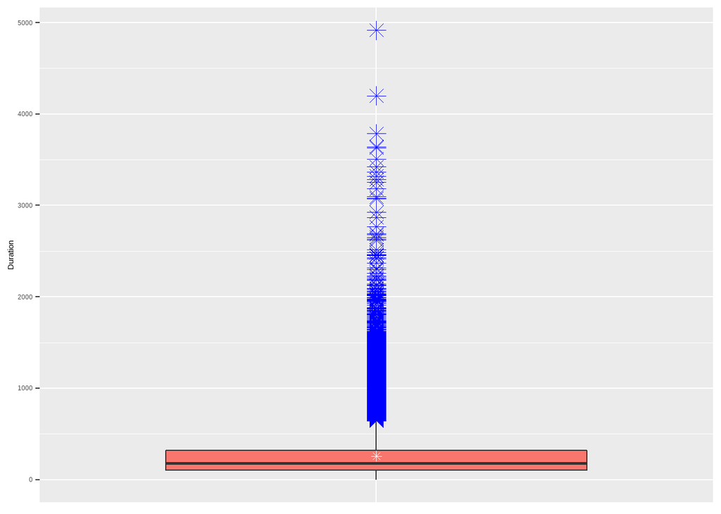

```r
bp2 <- ggplot(numerics, aes(x = factor(0), y = Duration, fill = factor(0))) +
  geom_boxplot(outlier.colour="blue", outlier.shape=8, outlier.size=4) +
  theme(axis.title.x=element_blank(),axis.text.x=element_blank(),axis.ticks.x=element_blank(),legend.position="none")+
  stat_summary(fun = "mean", geom = "point", shape = 8,
               size = 2, color = "white")
bp2
```

The boxplots Age and Duration show that both columns have a lot of outliers present. It is especially exhibited in Duration where the interquartile range is very small with a range of about 200. While the outliers can go all the way to around 5000s. We experimented with removing the outliers and running the models but they yielded no significant results. Thus, it was decided to keep the outliers as most of them were in columns that were related directly to the telemarketing campaign such as pdays, previous, campaign, and duration and most probably hold important information.

collecting integer columns

```r
integers <- subset(bank,select = names(Filter(is.integer,bank)))
```

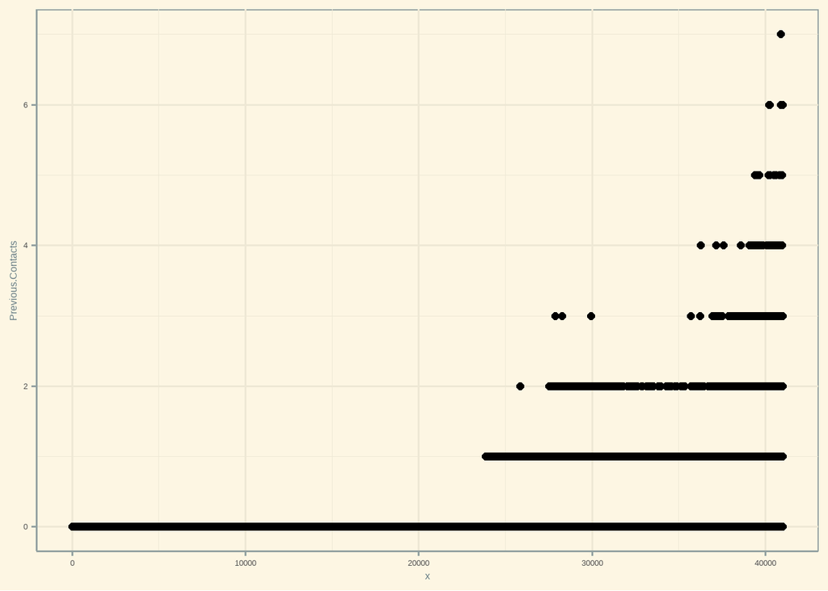

```r
x <- c(1:nrow(bank))
ggplot(integers, aes(x=x, y=Previous.Contacts)) +
    geom_point(size=2) +
    theme_solarized()
```

**Correlation numerical columns:** Parametric for Pearson, nonparametric for Spearman’s correlation

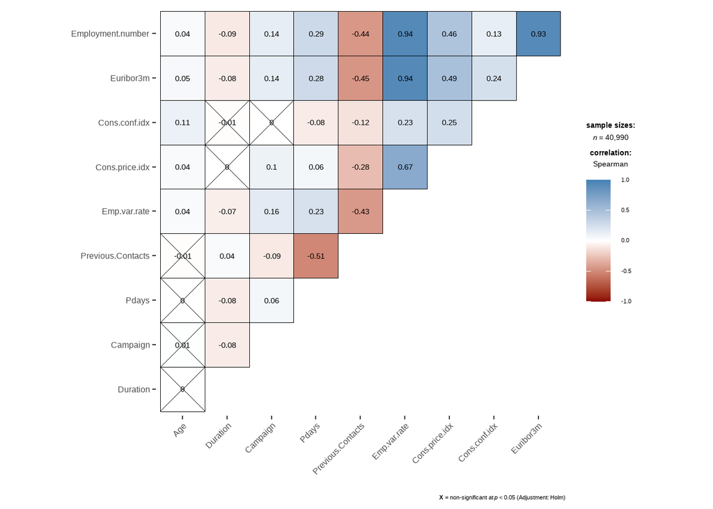

```r
ggstatsplot::ggcorrmat(data = bank, type = "nonparametric", colors = c("darkred", "white", "steelblue"))
```

#Statistical Analysis ##chi-square statistical test for correlation of categorical features

```r
summary(bank[Factorcols])
```

```
##              Job            Marital         Default
##  administration:10485   divorced: 4611   no     :32469
##  blue-collar   : 9344   married :24824   unknown: 8518
##  technician    : 6743   single  :11555   yes    :    3
##  services      : 3963
##  management    : 2921
##  retired       : 1725
##  (Other)       : 5809
##                Education        Housing           Loan            Contact
##  basic.4y           : 4318   no     :18526   no     :33782   cellular :26032
##  basic.6y           : 2286   unknown:  987   unknown:  987   telephone:14958
##  basic.9y           : 6489   yes    :21477   yes    : 6221
##  high.school        : 9817
##  illiterate         :   18
##  professional.course: 5448
##  university.degree  :12614
##      Month       Last.Contact.Day        Poutcome       y
##  may    :13699   fri:7796         failure    : 4236   no :36371
##  jul    : 7148   mon:8467         nonexistent:35391   yes: 4619
##  aug    : 6135   thu:8570         success    : 1363
##  jun    : 5284   tue:8056
##  nov    : 4092   wed:8101
##  apr    : 2627
##  (Other): 2005
```

## testing relationship between Factor columns and y(subscribed or unsubscribed)

measuring the effect size

```r
cramersv <- function(x,n,d){
  v <- sqrt(x/(n*d))
  return(v)
}
```

Effect size interpretation for cramersv for df=1: small(.1), medium(.3), large(.5) H0: There is no relationship(Independent) H1: There is a relationship(dependent)

```r
chisquare_test <- function(bank,Factorcols)
{  n <- nrow(bank)
  for(col in Factorcols[-length(Factorcols)]){
    if(col!="Default")
    {
      print(paste("*",col,"*"))
      print(table(bank[[col]],bank$y))
      chi <- chisq.test(bank[[col]],bank$y)
      print(chi)
      print(paste("effect size:",cramersv(chi$statistic,n,chi$parameter)))
    }
  }
}
```

```r
chisquare_test(bank,Factorcols)
```

```
## [1] "* Job *"
##
##                    no  yes
##   administration 9123 1362
##   blue-collar    8703  641
##   entrepreneur   1330  123
##   housemaid       951  106
##   management     2593  328
##   retired        1286  439
##   self-employed  1267  149
##   services       3640  323
##   student         599  275
##   technician     6014  729
##   unemployed      865  144
##
##  Pearson's Chi-squared test
##
## data:  bank[[col]] and bank$y
## X-squared = 979.04, df = 10, p-value < 2.2e-16
##
## [1] "effect size: 0.0488721275382095"
## [1] "* Marital *"
##
##               no   yes
##   divorced  4135   476
##   married  22299  2525
##   single    9937  1618
##
##  Pearson's Chi-squared test
##
## data:  bank[[col]] and bank$y
## X-squared = 120.38, df = 2, p-value < 2.2e-16
##
## [1] "effect size: 0.0383197800632542"
## [1] "* Education *"
##
##                          no   yes
##   basic.4y             3847   471
##   basic.6y             2098   188
##   basic.9y             5994   495
##   high.school          8709  1108
##   illiterate             14     4
##   professional.course  4828   620
##   university.degree   10881  1733
```

```
##
##  Pearson's Chi-squared test
##
## data:  bank[[col]] and bank$y
## X-squared = 186.96, df = 6, p-value < 2.2e-16
##
## [1] "effect size: 0.0275714940810703"
## [1] "* Housing *"
##
##              no   yes
##   no      16513  2013
##   unknown   880   107
##   yes     18978  2499
##
##  Pearson's Chi-squared test
##
## data:  bank[[col]] and bank$y
## X-squared = 6.0813, df = 2, p-value = 0.0478
##
## [1] "effect size: 0.00861276577315766"
## [1] "* Loan *"
##
##              no   yes
##   no      29951  3831
##   unknown   880   107
##   yes      5540   681
##
##  Pearson's Chi-squared test
##
## data:  bank[[col]] and bank$y
## X-squared = 0.99884, df = 2, p-value = 0.6069
##
## [1] "effect size: 0.00349055503649505"
## [1] "* Contact *"
##
##                no   yes
##   cellular  22194  3838
##   telephone 14177   781
##
##  Pearson's Chi-squared test with Yates' continuity correction
```

[output cut: 38 more lines]

```
##
## [1] "effect size: 0.0125370732017601"
## [1] "* Poutcome *"
##
##                  no   yes
##   failure      3634   602
##   nonexistent 32263  3128
##   success       474   889
##
##  Pearson's Chi-squared test
##
## data:  bank[[col]] and bank$y
## X-squared = 4214.1, df = 2, p-value < 2.2e-16
##
## [1] "effect size: 0.226725131514327"
```

**chi-squared test results** - The test gives the categorical columns are dependent on output-y but, the effect size is not so significant for all the cases except Poutcome

## Education category as illiterate are very few therefore dropping rows with illiterate

```r
bank <- subset(bank, Education!="illiterate")
```

dropping unused factor levels in Education

```r
bank$Education <- droplevels(bank$Education)
```

```r
levels(bank$Education)
```

```
## [1] "basic.4y"            "basic.6y"            "basic.9y"
## [4] "high.school"         "professional.course" "university.degree"
```

## testing correlation between numerical and output

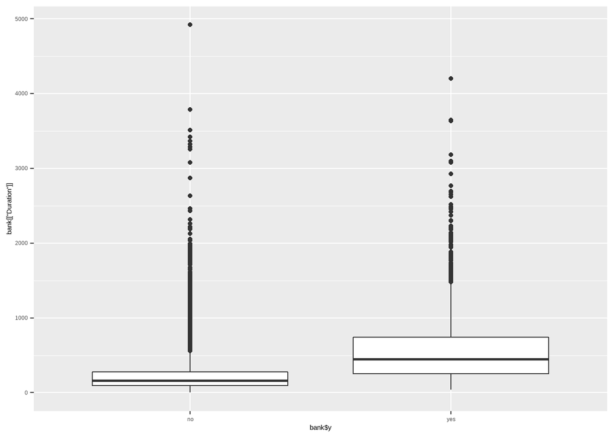

```r
graph <- ggplot() + geom_boxplot(aes(bank$y,bank[["Duration"]]))
graph
```

Since, the overlap of boxplot is lesser they are highly correleted with each other which is already given in problem description

##Anova for analysis of variances

```r
aov.dur <- aov(Duration~y,data=bank)
summary(aov.dur)
```

```
##                Df    Sum Sq  Mean Sq F value Pr(>F)
## y               1 4.530e+08 4.53e+08    8061 <2e-16 ***
## Residuals   40970 2.302e+09 5.62e+04
## ---
## Signif. codes:  0 '***' 0.001 '**' 0.01 '*' 0.05 '.' 0.1 ' ' 1
```

##Bartlett’s test for homogeneity of variances

```r
bartlettfornumerics <- function(bank,numerics){
  for(col in names(numerics)){
    print(paste("*",col,"*"))
    print(bartlett.test(bank[[col]],bank$y))
  }
}
```

```r
bartlettfornumerics(bank,numerics)
```

```
## [1] "* Age *"
##
##  Bartlett test of homogeneity of variances
##
## data:  bank[[col]] and bank$y
## Bartlett's K-squared = 1091.8, df = 1, p-value < 2.2e-16
##
## [1] "* Duration *"
##
##  Bartlett test of homogeneity of variances
##
## data:  bank[[col]] and bank$y
## Bartlett's K-squared = 4962, df = 1, p-value < 2.2e-16
##
## [1] "* Campaign *"
##
##  Bartlett test of homogeneity of variances
##
## data:  bank[[col]] and bank$y
## Bartlett's K-squared = 1828.4, df = 1, p-value < 2.2e-16
##
## [1] "* Pdays *"
##
##  Bartlett test of homogeneity of variances
##
## data:  bank[[col]] and bank$y
## Bartlett's K-squared = 20199, df = 1, p-value < 2.2e-16
##
## [1] "* Previous.Contacts *"
##
##  Bartlett test of homogeneity of variances
##
## data:  bank[[col]] and bank$y
## Bartlett's K-squared = 6479.6, df = 1, p-value < 2.2e-16
##
## [1] "* Emp.var.rate *"
##
##  Bartlett test of homogeneity of variances
##
## data:  bank[[col]] and bank$y
```

[output cut: 14 more lines]

```
## Bartlett's K-squared = 1091.9, df = 1, p-value < 2.2e-16
##
## [1] "* Euribor3m *"
##
##  Bartlett test of homogeneity of variances
##
## data:  bank[[col]] and bank$y
## Bartlett's K-squared = 31.144, df = 1, p-value = 2.396e-08
##
## [1] "* Employment.number *"
##
##  Bartlett test of homogeneity of variances
##
## data:  bank[[col]] and bank$y
## Bartlett's K-squared = 884.67, df = 1, p-value < 2.2e-16
```

```r
boxplotsnumericsvsy <- function(bank,numerics){
  for(col in names(numerics)){
    graph <- ggplot() + geom_boxplot(aes(bank$y,bank[[col]]))
    print(graph)
  }
}
```

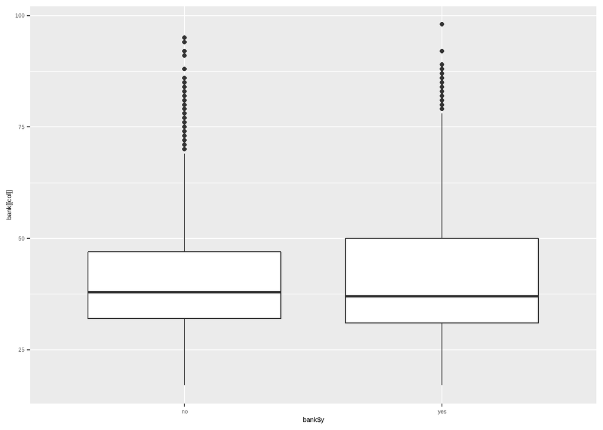

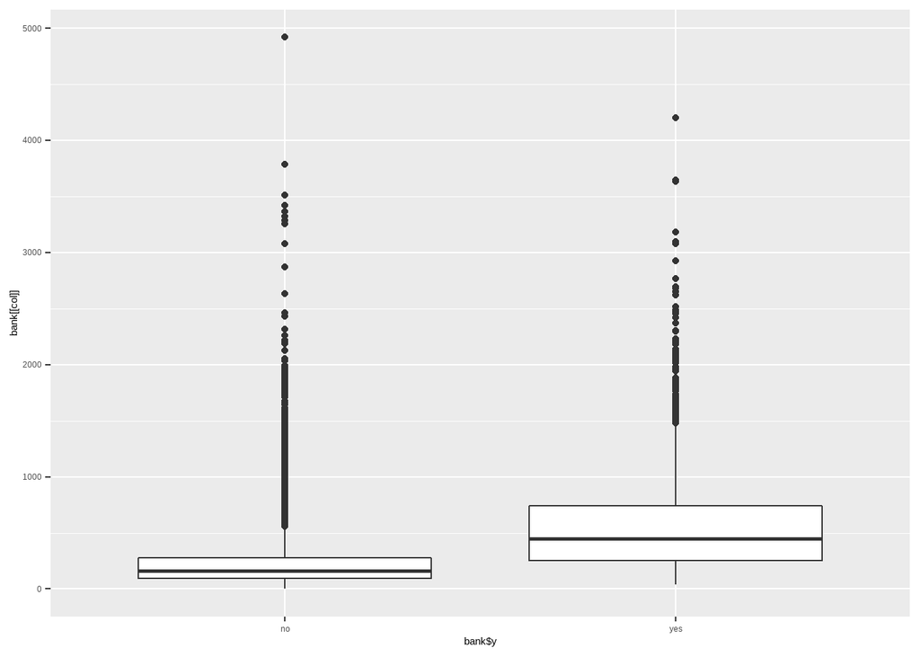

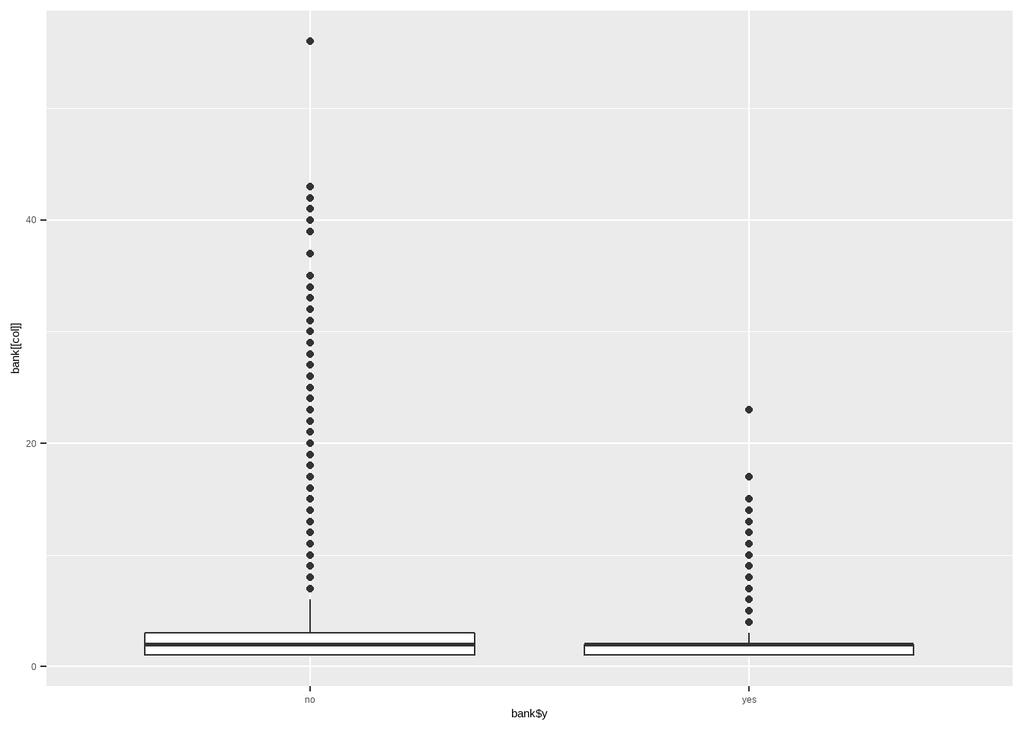

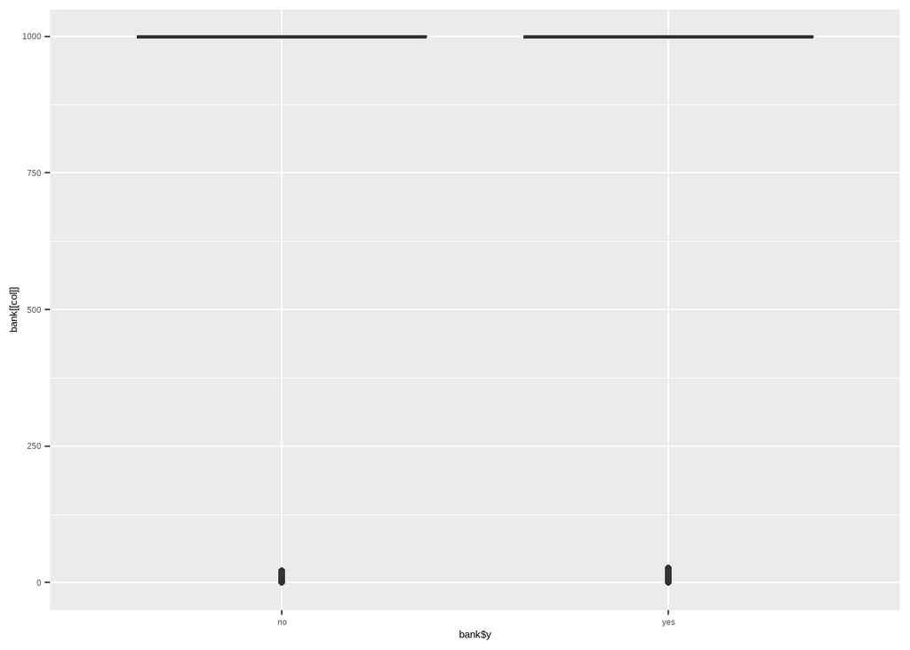

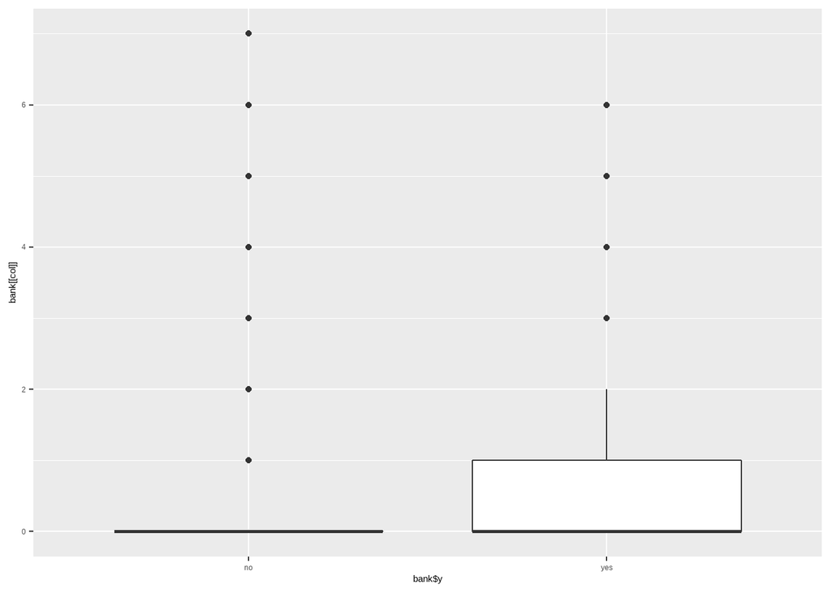

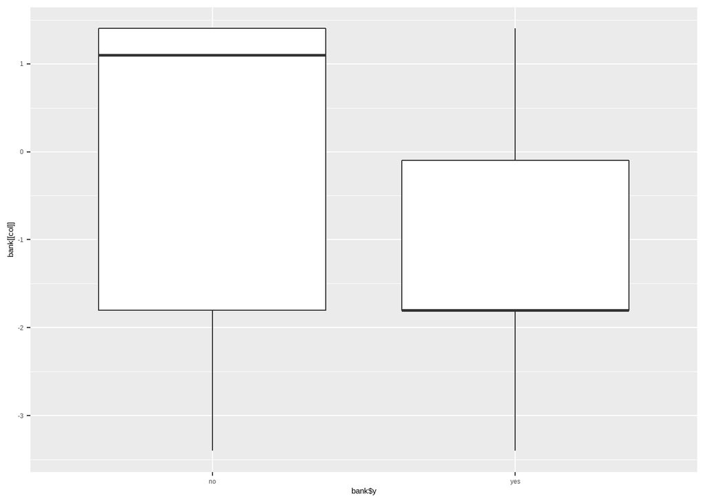

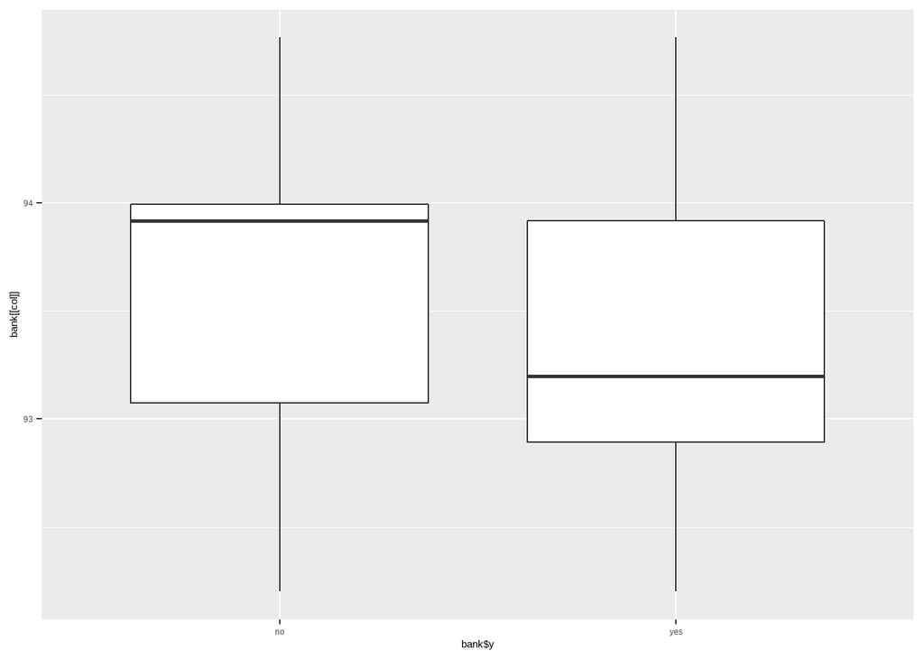

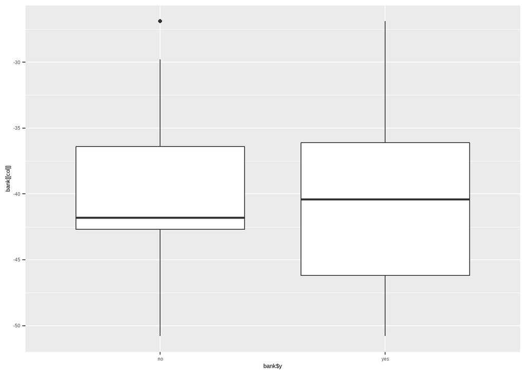

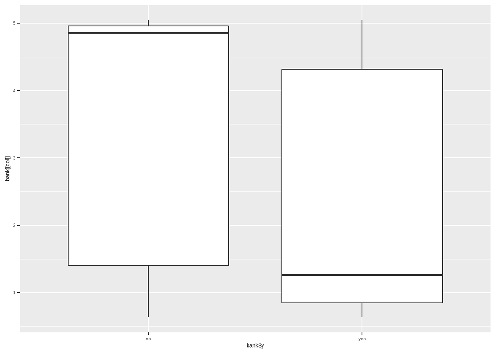

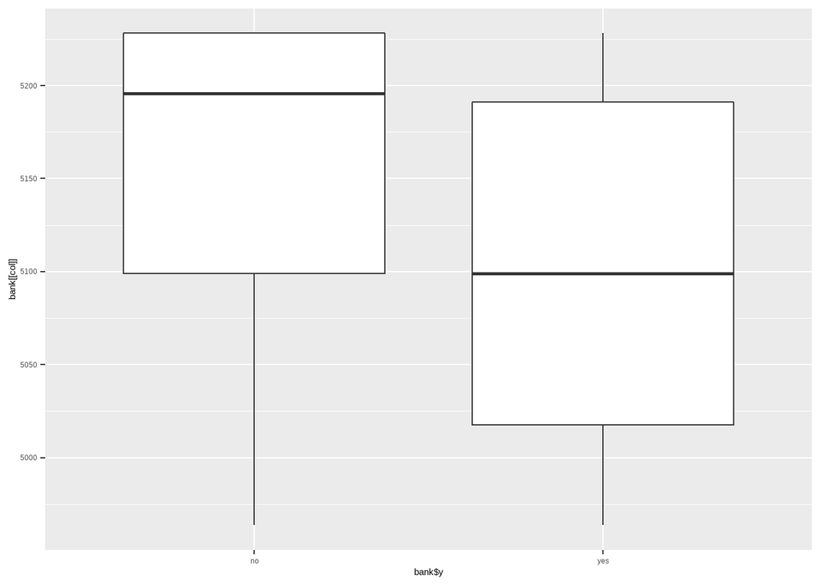

```r
boxplotsnumericsvsy(bank,numerics)
```

##data transformations

```r
summary(bank)
```

```
##       Age                 Job            Marital
##  Min.   :17   administration:10484   divorced: 4609
##  1st Qu.:32   blue-collar   : 9336   married :24809
##  Median :38   technician    : 6743   single  :11554
##  Mean   :40   services      : 3963
##  3rd Qu.:47   management    : 2921
##  Max.   :98   retired       : 1722
##               (Other)       : 5803
##                Education        Default         Housing           Loan
##  basic.4y           : 4318   no     :32458   no     :18518   no     :33767
##  basic.6y           : 2286   unknown: 8511   unknown:  987   unknown:  987
##  basic.9y           : 6489   yes    :    3   yes    :21467   yes    : 6218
##  high.school        : 9817
##  professional.course: 5448
##  university.degree  :12614
##
##       Contact          Month       Last.Contact.Day    Duration
##  cellular :26017   may    :13696   fri:7792         Min.   :   0.0
##  telephone:14955   jul    : 7143   mon:8466         1st Qu.: 102.0
##                    aug    : 6130   thu:8564         Median : 180.0
##                    jun    : 5284   tue:8051         Mean   : 258.3
##                    nov    : 4089   wed:8099         3rd Qu.: 319.0
##                    apr    : 2625                    Max.   :4918.0
##                    (Other): 2005
##     Campaign          Pdays       Previous.Contacts        Poutcome
##  Min.   : 1.000   Min.   :  0.0   Min.   :0.000     failure    : 4235
##  1st Qu.: 1.000   1st Qu.:999.0   1st Qu.:0.000     nonexistent:35375
##  Median : 2.000   Median :999.0   Median :0.000     success    : 1362
##  Mean   : 2.565   Mean   :962.6   Mean   :0.173
##  3rd Qu.: 3.000   3rd Qu.:999.0   3rd Qu.:0.000
##  Max.   :56.000   Max.   :999.0   Max.   :7.000
##
##   Emp.var.rate      Cons.price.idx  Cons.conf.idx      Euribor3m
##  Min.   :-3.40000   Min.   :92.20   Min.   :-50.80   Min.   :0.634
##  1st Qu.:-1.80000   1st Qu.:93.08   1st Qu.:-42.70   1st Qu.:1.344
##  Median : 1.10000   Median :93.75   Median :-41.80   Median :4.857
##  Mean   : 0.08055   Mean   :93.58   Mean   :-40.51   Mean   :3.620
##  3rd Qu.: 1.40000   3rd Qu.:93.99   3rd Qu.:-36.40   3rd Qu.:4.961
##  Max.   : 1.40000   Max.   :94.77   Max.   :-26.90   Max.   :5.045
##
##  Employment.number   y
##  Min.   :4964      no :36357
##  1st Qu.:5099      yes: 4615
##  Median :5191
##  Mean   :5167
##  3rd Qu.:5228
##  Max.   :5228
##
```

removing Default column because the ratio of yes to no is unbalanced

```r
bank <- subset(bank,select=-c(Default))
```

removing Duration since we can know the output only after the call has been made

```r
bank <- subset(bank,select=-c(Duration))
```

```r
levels(bank$y) <- c(0,1)
```

##handling categories

```r
bindata <- subset(dummy_cols(bank,remove_first_dummy = TRUE), select=-c(Job,Education,Month,Last.Contact.Day,Marital,Housing,Loan,Contact,Poutcome))
```

```r
bindata <- subset(bindata,select=-c(y_1))
```

##rescaling continuous columns

```r
str(bindata)
```

```
## 'data.frame':    40972 obs. of  47 variables:
##  $ Age                          : int  56 57 37 40 56 45 59 41 24 25 ...
##  $ Campaign                     : int  1 1 1 1 1 1 1 1 1 1 ...
##  $ Pdays                        : int  999 999 999 999 999 999 999 999 999 999 ...
##  $ Previous.Contacts            : int  0 0 0 0 0 0 0 0 0 0 ...
##  $ Emp.var.rate                 : num  1.1 1.1 1.1 1.1 1.1 1.1 1.1 1.1 1.1 1.1 ...
##  $ Cons.price.idx               : num  94 94 94 94 94 ...
##  $ Cons.conf.idx                : num  -36.4 -36.4 -36.4 -36.4 -36.4 -36.4 -36.4 -36.4 -36.4 -36.4 ...
##  $ Euribor3m                    : num  4.86 4.86 4.86 4.86 4.86 ...
##  $ Employment.number            : num  5191 5191 5191 5191 5191 ...
##  $ y                            : Factor w/ 2 levels "0","1": 1 1 1 1 1 1 1 1 1 1 ...
##  $ Job_blue-collar              : int  0 0 0 0 0 0 0 1 0 0 ...
##  $ Job_entrepreneur             : int  0 0 0 0 0 0 0 0 0 0 ...
##  $ Job_housemaid                : int  1 0 0 0 0 0 0 0 0 0 ...
##  $ Job_management               : int  0 0 0 0 0 0 0 0 0 0 ...
```

[output cut: 33 more lines]

```r
str(bank)
```

```
## 'data.frame':    40972 obs. of  19 variables:
##  $ Age              : int  56 57 37 40 56 45 59 41 24 25 ...
##  $ Job              : Factor w/ 11 levels "administration",..: 4 8 8 1 8 8 1 2 10 8 ...
##  $ Marital          : Factor w/ 3 levels "divorced","married",..: 2 2 2 2 2 2 2 2 3 3 ...
##  $ Education        : Factor w/ 6 levels "basic.4y","basic.6y",..: 1 4 4 2 4 3 5 3 5 4 ...
##  $ Housing          : Factor w/ 3 levels "no","unknown",..: 1 1 3 1 1 1 1 1 3 3 ...
##  $ Loan             : Factor w/ 3 levels "no","unknown",..: 1 1 1 1 3 1 1 1 1 1 ...
##  $ Contact          : Factor w/ 2 levels "cellular","telephone": 2 2 2 2 2 2 2 2 2 2 ...
##  $ Month            : Factor w/ 10 levels "apr","aug","dec",..: 7 7 7 7 7 7 7 7 7 7 ...
##  $ Last.Contact.Day : Factor w/ 5 levels "fri","mon","thu",..: 2 2 2 2 2 2 2 2 2 2 ...
##  $ Campaign         : int  1 1 1 1 1 1 1 1 1 1 ...
##  $ Pdays            : int  999 999 999 999 999 999 999 999 999 999 ...
##  $ Previous.Contacts: int  0 0 0 0 0 0 0 0 0 0 ...
##  $ Poutcome         : Factor w/ 3 levels "failure","nonexistent",..: 2 2 2 2 2 2 2 2 2 2 ...
##  $ Emp.var.rate     : num  1.1 1.1 1.1 1.1 1.1 1.1 1.1 1.1 1.1 1.1 ...
##  $ Cons.price.idx   : num  94 94 94 94 94 ...
##  $ Cons.conf.idx    : num  -36.4 -36.4 -36.4 -36.4 -36.4 -36.4 -36.4 -36.4 -36.4 -36.4 ...
##  $ Euribor3m        : num  4.86 4.86 4.86 4.86 4.86 ...
##  $ Employment.number: num  5191 5191 5191 5191 5191 ...
##  $ y                : Factor w/ 2 levels "0","1": 1 1 1 1 1 1 1 1 1 1 ...
```

minmax scaling

```r
minmax <- function(x) {
    return((x- min(x)) /(max(x)-min(x)))
}
```

```r
bank <- bank%>%mutate_if(is.numeric,minmax)
```

```r
bindata <- bindata%>%mutate_if(is.numeric,minmax)
```

# Split the data into training and test set

```r
set.seed(115)
trainIndices = sample(1:dim(bank)[1],round(.8 * dim(bank)[1]))
```

# Build bank test/train

```r
bank.train = bank[trainIndices,]
bank.test = bank[-trainIndices,]
```

```r
print(table(bank.train$y)/nrow(bank.train))
```

```
##
##         0         1
## 0.8862957 0.1137043
```

```r
print(table(bank.test$y)/nrow(bank.test))
```

```
##
##        0        1
## 0.891628 0.108372
```

```r
bank.test.class <- bank.test$y
bank.test <- subset(bank.test,select=-c(y))
```

# Build bindata test/train

```r
bin.train = bindata[trainIndices,]
bin.test = bindata[-trainIndices,]
```

```r
print(table(bin.train$y)/nrow(bin.train))
```

```
##
##         0         1
## 0.8862957 0.1137043
```

```r
print(table(bin.test$y)/nrow(bin.test))
```

```
##
##        0        1
## 0.891628 0.108372
```

```r
bin.test.class <- bin.test$y
bin.test <- subset(bin.test,select=-c(y))
```

#modelling

```r
library(e1071)
library(caTools)
library(class)
library(caret)
library(ROSE)
library(ROCR)
```

##Logistic Regression

Starting with the full model

```r
glm.out <- glm(y~.,data=bank.train, family = "binomial")
```

```r
summary(glm.out)
```

```
##
## Call:
## glm(formula = y ~ ., family = "binomial", data = bank.train)
##
## Deviance Residuals:
##     Min       1Q   Median       3Q      Max
## -2.1110  -0.3908  -0.3196  -0.2599   2.9658
##
## Coefficients: (1 not defined because of singularities)
##                                Estimate Std. Error z value Pr(>|z|)
## (Intercept)                  -1.2573025  0.5151832  -2.440 0.014667 *
## Age                          -0.1460792  0.1920763  -0.761 0.446940
## Jobblue-collar               -0.1173002  0.0788588  -1.487 0.136890
## Jobentrepreneur              -0.0043824  0.1180007  -0.037 0.970374
## Jobhousemaid                 -0.0938806  0.1482344  -0.633 0.526522
## Jobmanagement                -0.0253760  0.0834163  -0.304 0.760969
## Jobretired                    0.3401969  0.1060906   3.207 0.001343 **
## Jobself-employed             -0.0104956  0.1127120  -0.093 0.925810
## Jobservices                  -0.1042535  0.0849642  -1.227 0.219812
## Jobstudent                    0.2848847  0.1095732   2.600 0.009324 **
## Jobtechnician                 0.0002343  0.0712199   0.003 0.997375
## Jobunemployed                 0.0103556  0.1236843   0.084 0.933274
## Maritalmarried                0.0329193  0.0674172   0.488 0.625343
## Maritalsingle                 0.0290947  0.0771153   0.377 0.705959
## Educationbasic.6y             0.1950516  0.1131341   1.724 0.084694 .
## Educationbasic.9y            -0.0366701  0.0902569  -0.406 0.684533
## Educationhigh.school          0.0460973  0.0888163   0.519 0.603748
## Educationprofessional.course  0.0956247  0.0980003   0.976 0.329184
## Educationuniversity.degree    0.1700879  0.0888256   1.915 0.055511 .
## Housingunknown               -0.0977340  0.1334515  -0.732 0.463951
## Housingyes                   -0.0213076  0.0404615  -0.527 0.598461
## Loanunknown                          NA         NA      NA       NA
## Loanyes                      -0.0773423  0.0565385  -1.368 0.171325
## Contacttelephone             -0.7887348  0.0758115 -10.404  < 2e-16 ***
## Monthaug                      0.3743492  0.1206825   3.102 0.001923 **
## Monthdec                      0.5381976  0.2118717   2.540 0.011079 *
## Monthjul                      0.0489800  0.0934453   0.524 0.600169
## Monthjun                     -0.6306972  0.1235239  -5.106 3.29e-07 ***
## Monthmar                      1.4968538  0.1463015  10.231  < 2e-16 ***
## Monthmay                     -0.4397211  0.0808314  -5.440 5.33e-08 ***
```

[output cut: 12 more lines]

```
## Emp.var.rate                 -7.0228597  0.6689174 -10.499  < 2e-16 ***
## Cons.price.idx                5.3380864  0.6315784   8.452  < 2e-16 ***
## Cons.conf.idx                 0.8801959  0.1872645   4.700 2.60e-06 ***
## Euribor3m                     0.6511612  0.5666569   1.149 0.250503
## Employment.number             1.8949782  0.7984677   2.373 0.017631 *
## ---
## Signif. codes:  0 '***' 0.001 '**' 0.01 '*' 0.05 '.' 0.1 ' ' 1
##
## (Dispersion parameter for binomial family taken to be 1)
##
##     Null deviance: 23219  on 32777  degrees of freedom
## Residual deviance: 18080  on 32732  degrees of freedom
## AIC: 18172
##
## Number of Fisher Scoring iterations: 6
```

**Insights:** - Na’s above is due to two of the independent variables being perfectly collinear( Housing_unknown and loan_unknown) - Realized Housing and Personal Loan are collinear reason being client chooses to not disclose both together - The AIC for full model is 18172 and there is a significant difference between Null and Residual deviance - At first look, Job, Contact type, Month, Campaign, Pdays, Poutcome, Emp.var.rate,Cons.price.idx and cons.conf.idx are have significant influence on output - coefficient estimates of monthmarch, Campaign, Pdays, Emp.var.rate, Cons.price.index has the most influence with unit change in them

```r
stepmodel <- stepAIC(glm.out,direction = "backward",trace = FALSE)
stepmodel
```

```
##
## Call:  glm(formula = y ~ Job + Education + Contact + Month + Last.Contact.Day +
##     Campaign + Pdays + Poutcome + Emp.var.rate + Cons.price.idx +
##     Cons.conf.idx + Employment.number, family = "binomial", data = bank.train)
##
## Coefficients:
##                  (Intercept)                Jobblue-collar
##                    -1.837049                     -0.114682
##              Jobentrepreneur                  Jobhousemaid
##                    -0.010348                     -0.104402
##                Jobmanagement                    Jobretired
##                    -0.031733                      0.295164
##             Jobself-employed                   Jobservices
##                    -0.007536                     -0.104016
##                   Jobstudent                 Jobtechnician
##                     0.305759                      0.004669
##                Jobunemployed             Educationbasic.6y
##                     0.012630                      0.205582
##            Educationbasic.9y          Educationhigh.school
##                    -0.024806                      0.060860
## Educationprofessional.course    Educationuniversity.degree
##                     0.107723                      0.186258
##             Contacttelephone                      Monthaug
##                    -0.782207                      0.392166
##                     Monthdec                      Monthjul
##                     0.596197                      0.069404
##                     Monthjun                      Monthmar
##                    -0.639189                      1.544914
##                     Monthmay                      Monthnov
##                    -0.420445                     -0.380506
##                     Monthoct                      Monthsep
##                     0.045692                      0.223956
##          Last.Contact.Daymon           Last.Contact.Daythu
##                    -0.240146                      0.027603
##          Last.Contact.Daytue           Last.Contact.Daywed
##                     0.037400                      0.122790
##                     Campaign                         Pdays
##                    -2.127050                     -1.151519
##          Poutcomenonexistent               Poutcomesuccess
##                     0.550012                      0.739335
##                 Emp.var.rate                Cons.price.idx
##                    -6.932523                      5.604686
##                Cons.conf.idx             Employment.number
##                     1.023976                      2.575396
##
## Degrees of Freedom: 32777 Total (i.e. Null);  32740 Residual
## Null Deviance:       23220
## Residual Deviance: 18090     AIC: 18160
```

#loading model

```r
bootmod <- readRDS("./final_model.rds")
```

```r
bootmod
```

```
##
## Summary of Bootstrapping the 'stepAIC()' procedure for
##
## Call:
## glm(formula = y ~ ., family = "binomial", data = bank.train)
##
## Bootstrap samples: 50
## Direction: backward
## Penalty: 2 * df
##
## Covariates selected
##                   (%)
## Cons.conf.idx     100
## Cons.price.idx    100
## Contact           100
## Emp.var.rate      100
## Job               100
## Last.Contact.Day  100
## Month             100
## Pdays             100
## Poutcome          100
## Campaign           98
## Education          82
## Employment.number  82
## Euribor3m          44
## Loan               36
## Age                32
## Previous.Contacts  26
## Housing            18
## Marital            16
##
## Coefficients Sign
##                               + (%)  - (%)
## Cons.conf.idx                100.00   0.00
## Cons.price.idx               100.00   0.00
## Educationuniversity.degree   100.00   0.00
## Employment.number            100.00   0.00
## Euribor3m                    100.00   0.00
## Jobretired                   100.00   0.00
## Last.Contact.Daywed          100.00   0.00
```

[output cut: 148 more lines]

```
##
## Final Model:
## y ~ Job + Education + Contact + Month + Last.Contact.Day + Campaign +
##     Pdays + Poutcome + Emp.var.rate + Cons.price.idx + Cons.conf.idx +
##     Employment.number
##
##
##                  Step Df  Deviance Resid. Df Resid. Dev      AIC
## 1                                      32732   18080.41 18172.41
## 2           - Marital  2 0.2396035     32734   18080.65 18168.65
## 3           - Housing  1 0.2757271     32735   18080.92 18166.92
## 4              - Loan  2 2.2873374     32737   18083.21 18165.21
## 5               - Age  1 0.7662522     32738   18083.98 18163.98
## 6 - Previous.Contacts  1 0.9031918     32739   18084.88 18162.88
## 7         - Euribor3m  1 1.3187374     32740   18086.20 18162.20
```

Fitting best model got from bootstrap stepwise AIC

```r
best.model <- glm(y ~ Job + Education + Contact + Month + Last.Contact.Day + Campaign +
    Pdays + Poutcome + Emp.var.rate + Cons.price.idx + Cons.conf.idx +
    Employment.number,data=bank.train,family = "binomial")
```

```r
summary(best.model)
```

```
##
## Call:
## glm(formula = y ~ Job + Education + Contact + Month + Last.Contact.Day +
##     Campaign + Pdays + Poutcome + Emp.var.rate + Cons.price.idx +
##     Cons.conf.idx + Employment.number, family = "binomial", data = bank.train)
##
## Deviance Residuals:
##     Min       1Q   Median       3Q      Max
## -2.1054  -0.3905  -0.3209  -0.2565   2.9762
##
## Coefficients:
##                               Estimate Std. Error z value Pr(>|z|)
## (Intercept)                  -1.837049   0.345994  -5.309 1.10e-07 ***
## Jobblue-collar               -0.114682   0.078537  -1.460 0.144226
## Jobentrepreneur              -0.010348   0.117389  -0.088 0.929755
## Jobhousemaid                 -0.104402   0.147846  -0.706 0.480092
## Jobmanagement                -0.031733   0.082455  -0.385 0.700351
## Jobretired                    0.295164   0.092565   3.189 0.001429 **
## Jobself-employed             -0.007536   0.112572  -0.067 0.946625
## Jobservices                  -0.104016   0.084854  -1.226 0.220267
## Jobstudent                    0.305759   0.104105   2.937 0.003314 **
## Jobtechnician                 0.004669   0.071139   0.066 0.947672
## Jobunemployed                 0.012630   0.123535   0.102 0.918567
## Educationbasic.6y             0.205582   0.112640   1.825 0.067981 .
## Educationbasic.9y            -0.024806   0.089489  -0.277 0.781630
## Educationhigh.school          0.060860   0.087392   0.696 0.486178
## Educationprofessional.course  0.107723   0.097186   1.108 0.267680
## Educationuniversity.degree    0.186258   0.087092   2.139 0.032466 *
## Contacttelephone             -0.782207   0.075558 -10.352  < 2e-16 ***
## Monthaug                      0.392166   0.119120   3.292 0.000994 ***
## Monthdec                      0.596197   0.203256   2.933 0.003355 **
## Monthjul                      0.069404   0.092196   0.753 0.451576
## Monthjun                     -0.639189   0.122665  -5.211 1.88e-07 ***
## Monthmar                      1.544914   0.139630  11.064  < 2e-16 ***
## Monthmay                     -0.420445   0.079096  -5.316 1.06e-07 ***
## Monthnov                     -0.380506   0.093797  -4.057 4.98e-05 ***
## Monthoct                      0.045692   0.126066   0.362 0.717017
## Monthsep                      0.223956   0.158314   1.415 0.157176
## Last.Contact.Daymon          -0.240146   0.064322  -3.734 0.000189 ***
## Last.Contact.Daythu           0.027603   0.062258   0.443 0.657505
## Last.Contact.Daytue           0.037400   0.063848   0.586 0.558032
## Last.Contact.Daywed           0.122790   0.063632   1.930 0.053646 .
## Campaign                     -2.127050   0.554536  -3.836 0.000125 ***
## Pdays                        -1.151519   0.211903  -5.434 5.51e-08 ***
## Poutcomenonexistent           0.550012   0.063358   8.681  < 2e-16 ***
## Poutcomesuccess               0.739335   0.213574   3.462 0.000537 ***
## Emp.var.rate                 -6.932523   0.666561 -10.400  < 2e-16 ***
## Cons.price.idx                5.604686   0.569632   9.839  < 2e-16 ***
## Cons.conf.idx                 1.023976   0.130896   7.823 5.17e-15 ***
## Employment.number             2.575396   0.532256   4.839 1.31e-06 ***
## ---
## Signif. codes:  0 '***' 0.001 '**' 0.01 '*' 0.05 '.' 0.1 ' ' 1
##
## (Dispersion parameter for binomial family taken to be 1)
##
##     Null deviance: 23219  on 32777  degrees of freedom
## Residual deviance: 18086  on 32740  degrees of freedom
## AIC: 18162
##
## Number of Fisher Scoring iterations: 6
```

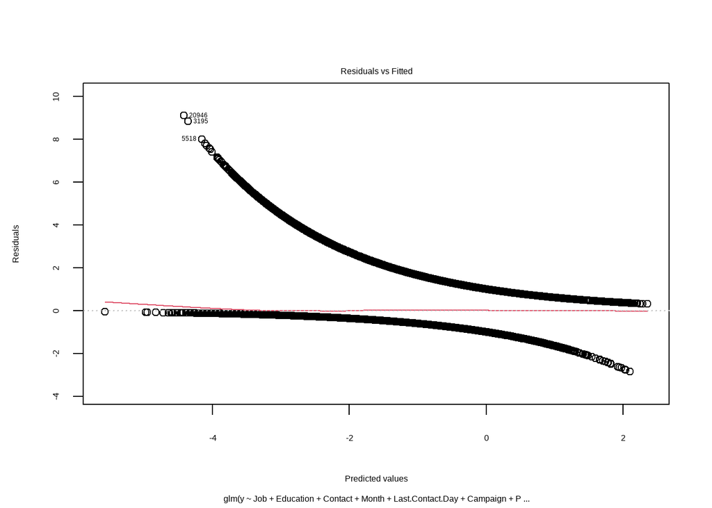

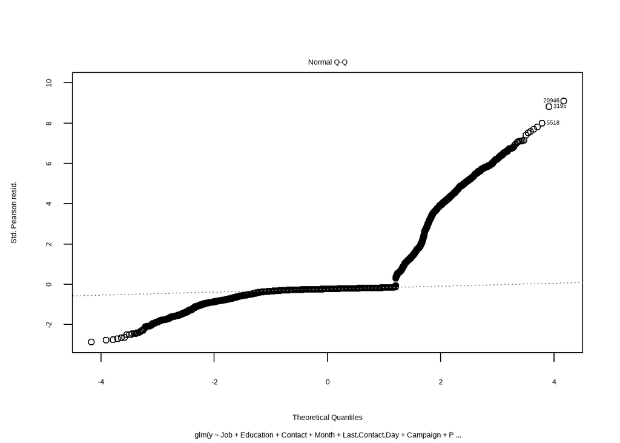

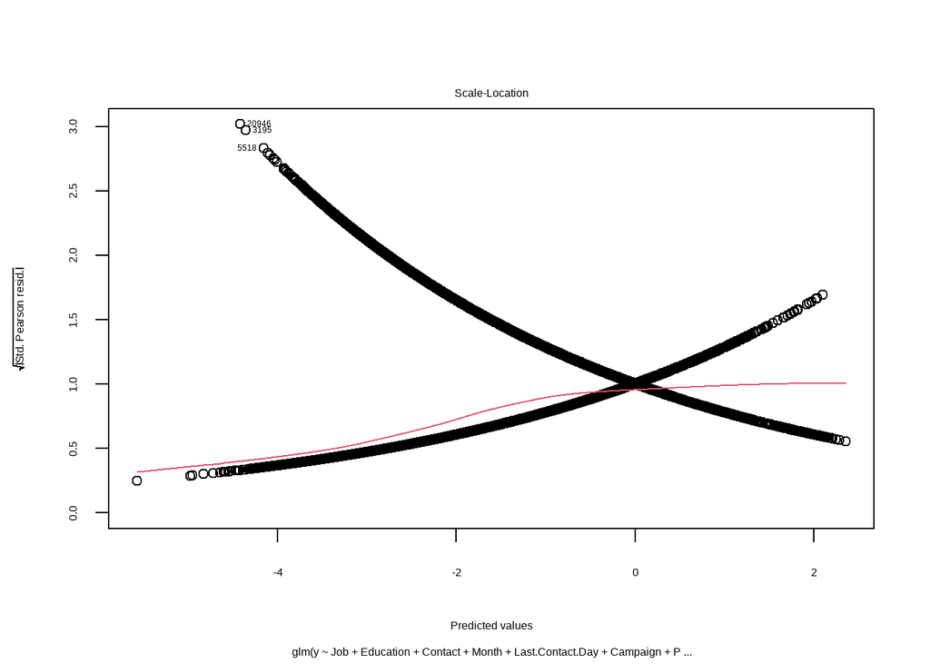

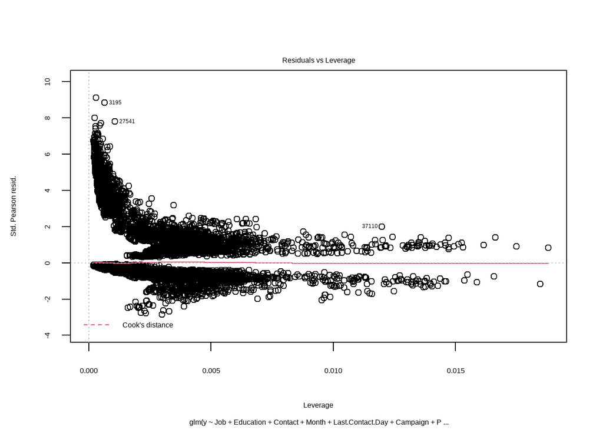

```r
plot(best.model)
```

1)These plots have been made for linear models, they help us to identify some irregularities in the data, but they don’t have to affect the model since they are not have been designed for logistic regression. 2) In the first plot lower line is showing the negative residuals when we are predicting the label as 0 and the superior line of points is when we have positive residuals when predicting 1. 3)The second plot helps us to find out if we are using the right distribution and to detect skewness in our data, we can observe that is skewed and doesn’t fit adequately to the dashed line which would be the ideal scenario. 4)This third plot helps us to identify homoscedasticity in the residuals from this spread we can infer that the residuals are spread wider and then decrease. 5)The fouth graph shows the Cooks distance to identify the influence that have the outliers, overall we can observe that they don’t have a big effect because all the points are spread along the red dashed line.

interpreting odds ratio

```r
oddsratio <- data.frame(exp(best.model$coefficients))
oddsratio
```

|  | exp.best.model.coefficients. |
| --- | --- |
| (Intercept) | 1.592868e-01 |
| Jobblue-collar | 8.916498e-01 |
| Jobentrepreneur | 9.897052e-01 |
| Jobhousemaid | 9.008628e-01 |
| Jobmanagement | 9.687657e-01 |
| Jobretired | 1.343347e+00 |
| Jobself-employed | 9.924921e-01 |
| Jobservices | 9.012110e-01 |
| Jobstudent | 1.357655e+00 |
| Jobtechnician | 1.004680e+00 |

[output cut: 28 more lines]

seeing for any VIF

```r
car::vif(best.model)
```

```
##                         GVIF Df GVIF^(1/(2*Df))
## Job                 3.771678 10        1.068628
## Education           3.359351  5        1.128822
## Contact             2.425169  1        1.557295
## Month              27.190240  9        1.201405
## Last.Contact.Day    1.047319  4        1.005796
## Campaign            1.042488  1        1.021023
## Pdays               9.448266  1        3.073803
## Poutcome           10.594971  2        1.804160
## Emp.var.rate      144.033959  1       12.001415
## Cons.price.idx     53.853756  1        7.338512
## Cons.conf.idx       2.602511  1        1.613230
## Employment.number  75.155914  1        8.669251
```

```r
best.model1 <- glm(y ~ Job + Education + Contact + Month + Last.Contact.Day + Campaign +
    Pdays + Poutcome + Cons.price.idx + Cons.conf.idx +
    Employment.number,data=bank.train,family = "binomial")
```

```r
car::vif(best.model1)
```

```
##                        GVIF Df GVIF^(1/(2*Df))
## Job                3.767926 10        1.068575
## Education          3.367212  5        1.129086
## Contact            1.900338  1        1.378527
## Month              5.112846  9        1.094889
## Last.Contact.Day   1.044074  4        1.005406
## Campaign           1.040604  1        1.020100
## Pdays              9.436236  1        3.071846
## Poutcome          10.562847  2        1.802790
## Cons.price.idx     1.882988  1        1.372220
## Cons.conf.idx      2.293264  1        1.514353
## Employment.number  2.098835  1        1.448736
```

```r
summary(best.model1)
```

```
##
## Call:
## glm(formula = y ~ Job + Education + Contact + Month + Last.Contact.Day +
##     Campaign + Pdays + Poutcome + Cons.price.idx + Cons.conf.idx +
##     Employment.number, family = "binomial", data = bank.train)
##
## Deviance Residuals:
##     Min       1Q   Median       3Q      Max
## -2.1921  -0.3938  -0.3250  -0.2551   2.9968
##
## Coefficients:
##                                Estimate Std. Error z value Pr(>|z|)
## (Intercept)                   0.7383418  0.2408773   3.065 0.002175 **
## Jobblue-collar               -0.1256084  0.0785121  -1.600 0.109630
## Jobentrepreneur               0.0015065  0.1171113   0.013 0.989736
## Jobhousemaid                 -0.1107733  0.1472191  -0.752 0.451788
## Jobmanagement                -0.0302277  0.0822008  -0.368 0.713075
## Jobretired                    0.3255445  0.0920386   3.537 0.000405 ***
## Jobself-employed             -0.0003107  0.1120773  -0.003 0.997788
## Jobservices                  -0.1096263  0.0846959  -1.294 0.195544
## Jobstudent                    0.3295450  0.1037242   3.177 0.001487 **
## Jobtechnician                -0.0200663  0.0707188  -0.284 0.776603
## Jobunemployed                 0.0031783  0.1235209   0.026 0.979472
## Educationbasic.6y             0.2086569  0.1127230   1.851 0.064161 .
## Educationbasic.9y            -0.0149365  0.0893547  -0.167 0.867245
## Educationhigh.school          0.0593791  0.0873653   0.680 0.496717
## Educationprofessional.course  0.1016416  0.0970727   1.047 0.295069
## Educationuniversity.degree    0.1790453  0.0870118   2.058 0.039618 *
## Contacttelephone             -0.5210061  0.0674987  -7.719 1.17e-14 ***
## Monthaug                     -0.3032106  0.0992104  -3.056 0.002241 **
## Monthdec                      0.1787919  0.1978971   0.903 0.366282
## Monthjul                      0.1382763  0.0909884   1.520 0.128583
## Monthjun                      0.2420050  0.0890664   2.717 0.006585 **
## Monthmar                      0.7900992  0.1215627   6.500 8.06e-11 ***
## Monthmay                     -0.7359764  0.0725790 -10.140  < 2e-16 ***
## Monthnov                     -0.4400200  0.0934616  -4.708 2.50e-06 ***
## Monthoct                     -0.3568712  0.1237028  -2.885 0.003915 **
## Monthsep                     -0.6641458  0.1351169  -4.915 8.86e-07 ***
## Last.Contact.Daymon          -0.2535979  0.0640991  -3.956 7.61e-05 ***
## Last.Contact.Daythu           0.0107951  0.0619277   0.174 0.861615
## Last.Contact.Daytue           0.0143894  0.0636035   0.226 0.821018
## Last.Contact.Daywed           0.0950994  0.0633458   1.501 0.133285
## Campaign                     -2.2939666  0.5583876  -4.108 3.99e-05 ***
## Pdays                        -1.2007223  0.2109326  -5.692 1.25e-08 ***
## Poutcomenonexistent           0.5456340  0.0631671   8.638  < 2e-16 ***
## Poutcomesuccess               0.7015141  0.2124949   3.301 0.000962 ***
## Cons.price.idx               -0.1896196  0.1079512  -1.757 0.078998 .
## Cons.conf.idx                 0.5909928  0.1224579   4.826 1.39e-06 ***
## Employment.number            -2.8865492  0.0883866 -32.658  < 2e-16 ***
## ---
## Signif. codes:  0 '***' 0.001 '**' 0.01 '*' 0.05 '.' 0.1 ' ' 1
##
## (Dispersion parameter for binomial family taken to be 1)
##
##     Null deviance: 23219  on 32777  degrees of freedom
## Residual deviance: 18194  on 32741  degrees of freedom
## AIC: 18268
##
## Number of Fisher Scoring iterations: 6
```

**Takeaway:** - It is not always preferred to take out multicollinearity induced in the models

confusion matrix for best model

```r
pred_prob <- predict(best.model, bank.test ,type="response")
```

histogram of prediction probability

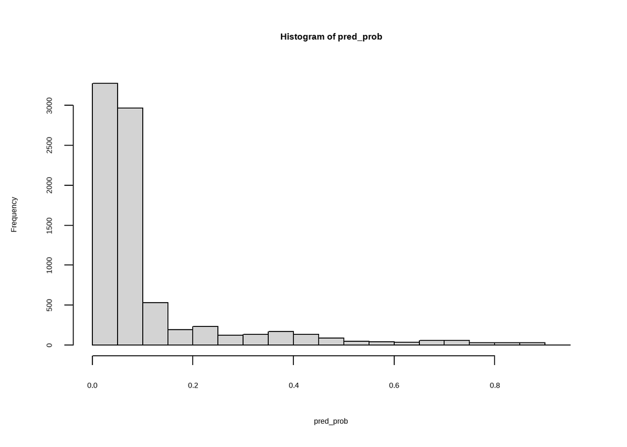

```r
hist(pred_prob)
```

```r
confusionMatrix(table(Predicted=ifelse(pred_prob>0.5,1,0),Actual=bank.test.class))
```

```
## Confusion Matrix and Statistics
##
##          Actual
## Predicted    0    1
##         0 7181  678
##         1  125  210
##
##                Accuracy : 0.902
##                  95% CI : (0.8954, 0.9084)
##     No Information Rate : 0.8916
##     P-Value [Acc > NIR] : 0.001175
##
##                   Kappa : 0.302
##
##  Mcnemar's Test P-Value : < 2.2e-16
##
##             Sensitivity : 0.9829
##             Specificity : 0.2365
##          Pos Pred Value : 0.9137
##          Neg Pred Value : 0.6269
##              Prevalence : 0.8916
##          Detection Rate : 0.8764
##    Detection Prevalence : 0.9591
##       Balanced Accuracy : 0.6097
##
##        'Positive' Class : 0
##
```

#AUC-ROC-curve

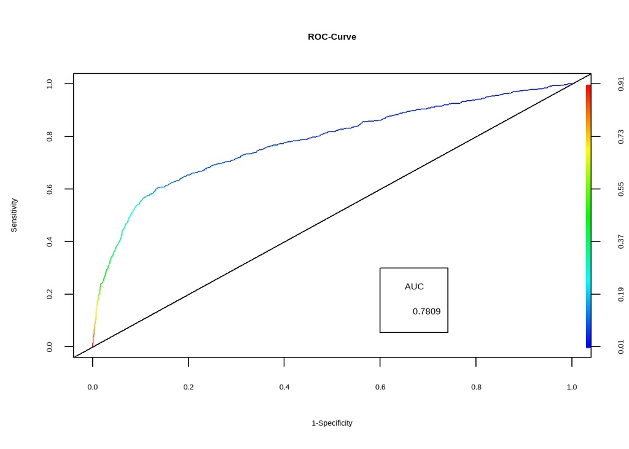

```r
pred <- prediction(pred_prob,bin.test.class)
perf <- performance(pred,"tpr","fpr")
plot(perf,colorize=TRUE,main="ROC-Curve",xlab="1-Specificity",ylab="Sensitivity")
abline(a=0,b=1)
auc <- performance(pred,"auc")
auc <- unlist(slot(auc,"y.values"))
auc <- round(auc,4)
legend(.6,.3,auc,title="AUC",cex = 1.2)
```

## understanding Logistic Regression